# Biodiversity of macrozoobenthic communities - 2

2019-05-25

## Biodiversity, taxonomic distinctness & graphical community analyses

This is a continuation of the community analyses started in part 1. Includes the selection of more sophisticated descriptive community analyses of biodiversity, again applied on the 3 separate datasets.

Some setup, to make this notebook stand-alone.

Define the working subdirectories.

```r
## print the working directory, just to be on the safe side
paste("You are here: ", getwd())
```

```
[1] "You are here:  /media/sklayn/data/data/rabota/documents/phd/thesis/4-results-discussion/data-n-analyses/results-analysis"
```

```r
data.dir <- "data"    # input data files
functions.dir <- "R"  # functions & scripts
save.dir <- "output"  # clean data, output from models & more complex calculations
figures.dir <- "figs" # plots & figures
```

Import the necessary libraries.

`r`r library(here) library(vegan) library(tidyverse) library(viridis)

Import functions.

```r
source(here(functions.dir, "alpha_diversity.R"))
source(here(functions.dir, "graphical_analyses.R"))
```

Organize some commonly-used ggplot2 modifications into a more convenient (and less repetitive) format.

```r
## ggplot settings & things that I keep reusing
# ggplot_theme <- list(
#   theme_bw(),
#   theme(element_text(family = "Times"))
# )
## always use black-and-white theme
theme_set(theme_bw())

## helper to adjust ggplot text size & avoid repetitions
text_size <- function(text.x = NULL,
                      text.y = NULL,
                      title.x = NULL,
                      title.y = NULL,
                      legend.text = NULL,
                      legend.title = NULL,
                      strip.x = NULL,
                      strip.y = NULL) {
  theme(axis.text.x = element_text(size = text.x),
        axis.text.y = element_text(size = text.y),
        axis.title.x = element_text(size = title.x),
        axis.title.y = element_text(size = title.y),
        legend.text = element_text(size = legend.text),
        legend.title = element_text(size = legend.title),
        strip.text.x = element_text(size = strip.x),
        strip.text.y = element_text(size = strip.y)
        )
}

## define a custom transformation and its inverse for the y axis of the ABC curves (modified logistic transformation) using the scales package (for ggplot graphics).
modif_logistic_trans <- function() scales::trans_new("modif_logistic",
                                                     function(x) log((1 + x)/(101 - x)),
                                                     function(x) exp((1 + x)/(101 - x)))
```

#### Macrozoobenthic communities in the sandy sediments of Burgas Bay (2013-2014)

Import the zoobenthic abundance & biomass data - as an exception, from the cleaned & saved datasets, to avoid (most of) the cleaning steps.

```r
## dimensions should be 54 x 205 (5 metadata + 200 species columns); all species columns should be numeric.
zoo.abnd.sand <- read_csv(here::here(save.dir, "abnd_sand_orig_clean.csv"))

## same for biomass; same expected structure as the abundance
zoo.biomass.sand <- read_csv(here::here(save.dir, "biomass_sand_orig_clean.csv"))
```

Convert columns to the proper type, arrange the datasets by station, etc.

```r
zoo.abnd.sand <- zoo.abnd.sand %>%
  mutate(station = factor(station, levels = c("Kraimorie", "Chukalya", "Akin", "Sozopol", "Agalina", "Paraskeva"))) %>%
  arrange(station, year, month)

zoo.biomass.sand <- zoo.biomass.sand %>%
  mutate(station = factor(station, levels = c("Kraimorie", "Chukalya", "Akin", "Sozopol", "Agalina", "Paraskeva"))) %>%
  arrange(station, year, month)
```

Remove all species not present in the datasets (= all-0 columns).

```r
## result should have dimensions 54 x 152 (147 species + 5 metadata columns)
zoo.abnd.sand <- zoo.abnd.sand %>%
  gather(key = species, value = sp_count, -c(station:replicate)) %>%
  group_by(species) %>%
  filter(sp_count > 0) %>%
  spread(species, sp_count, fill = 0) %>%
  arrange(station, year, month)

zoo.biomass.sand <- zoo.biomass.sand %>%
  gather(key = species, value = sp_biomass, -c(station:replicate)) %>%
  group_by(species) %>%
  filter(sp_biomass > 0) %>%
  spread(species, sp_biomass, fill = 0) %>%
  arrange(station, year, month)
```

Transform to long format, because for some functions it’s better.

```r
zoo.abnd.sand.long <- zoo.abnd.sand %>%
  gather(key = species, value = sp_count, -c(station:replicate))

zoo.biomass.sand.long <- zoo.biomass.sand %>%
  gather(key = species, value = sp_biomass, -c(station:replicate))
```

##### Alpha diversity indices

`r`r ## uses custom function for convenience - has to be imported first! alpha.div.sand <- zoo.abnd.sand %>% select(-c(station:replicate)) %>% alpha_diversity() ## add the metadata columns (row order is not changed, so possible) (alpha.div.sand <- bind_cols(zoo.abnd.sand %>% select(station:replicate), alpha.div.sand) )

| station | month | year | habitat | replicate | sp_richness | shannon_h | evenness_j | h_effective |
| --- | --- | --- | --- | --- | --- | --- | --- | --- |
| Kraimorie | 6 | 2013 | S | a | 31 | 2.5240592 | 0.7350229 | 12.479149 |
| Kraimorie | 6 | 2013 | S | b | 29 | 2.2163109 | 0.6581872 | 9.173427 |
| Kraimorie | 6 | 2013 | S | c | 33 | 2.5680322 | 0.7344563 | 13.040138 |
| Kraimorie | 9 | 2013 | S | a | 31 | 2.3676733 | 0.6894823 | 10.672531 |
| Kraimorie | 9 | 2013 | S | b | 28 | 2.0749241 | 0.6226881 | 7.963942 |
| Kraimorie | 9 | 2013 | S | c | 28 | 2.4371109 | 0.7313810 | 11.439942 |
| Kraimorie | 7 | 2014 | S | a | 25 | 2.1231342 | 0.6595887 | 8.357290 |
| Kraimorie | 7 | 2014 | S | b | 37 | 2.4381986 | 0.6752296 | 11.452392 |
| Kraimorie | 7 | 2014 | S | c | 32 | 2.3816473 | 0.6871981 | 10.822716 |
| Chukalya | 6 | 2013 | S | a | 20 | 2.1399181 | 0.7143222 | 8.498741 |

[output cut: 44 more lines]

Summarize these diversity indices by station & year.

`r`r ## might be a good place to eventually learn how to use the functions from package sjPlot for printing pretty (and easy!) tables…  
alpha.div.sand %>% group_by(station, year) %>% summarise(h_mean = mean(shannon_h), h_sd = sd(shannon_h), j_mean = mean(evenness_j), j_sd = sd(evenness_j), h_eff_mean = mean(h_effective), h_eff_sd = sd(h_effective) )

| station | year | h_mean | h_sd | j_mean | j_sd | h_eff_mean | h_eff_sd |
| --- | --- | --- | --- | --- | --- | --- | --- |
| Kraimorie | 2013 | 2.3646851 | 0.1886695 | 0.6952030 | 0.04710966 | 10.794855 | 1.9469125 |
| Kraimorie | 2014 | 2.3143267 | 0.1679745 | 0.6740055 | 0.01384535 | 10.210799 | 1.6357705 |
| Chukalya | 2013 | 2.5294674 | 0.2370399 | 0.7688633 | 0.03597607 | 12.832319 | 2.8777748 |
| Chukalya | 2014 | 2.6733810 | 0.1656564 | 0.7622609 | 0.04094071 | 14.621796 | 2.4162012 |
| Akin | 2013 | 1.7613879 | 0.3108124 | 0.5536498 | 0.08917967 | 6.057661 | 1.8608519 |
| Akin | 2014 | 1.8942137 | 0.2893525 | 0.5968377 | 0.08686297 | 6.841065 | 2.0622153 |
| Sozopol | 2013 | 0.8852428 | 0.2264205 | 0.3051631 | 0.07017252 | 2.480793 | 0.6412065 |
| Sozopol | 2014 | 1.4083489 | 0.2380566 | 0.4622940 | 0.08164176 | 4.168511 | 1.0166596 |
| Agalina | 2013 | 2.8588691 | 0.1308260 | 0.7859071 | 0.04442069 | 17.561912 | 2.1709188 |
| Agalina | 2014 | 2.5215057 | 0.3356502 | 0.6798132 | 0.09725527 | 12.897126 | 3.9694863 |

[output cut: 2 more lines]

2. Species accumulation curves - see how species are added when the number of samples (sites) increases. Usually used to see if the sampling effort is adequate & captures most of the diversity in the study area.

[output not shown]

```
Saving 15 x 8.86 cm image
```

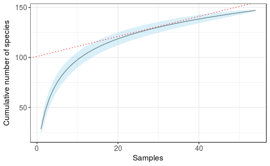

`r`r rm(sac.data.sand)

About 30 samples seem to be enough to capture most of the biodiversity in the study area (in terms of species richness) - this is where the curve starts to smooth out (slope < 1). In my dataset, there are 54 samples in total - could be considered enough.  
NB IF this method is applied correctly, since the samples are not independent but in fact represent replicates at each station.

##### Species pool

The species pool is the total extrapolated number of species in the study area (various estimates used here). Used to estimate the number of **unobserved species**. The functions assume that the number of unobserved species is related to he number of rare species (= seen only once or twice).

`r`r ## this function is based on incidences in sample sites - presence/absence data; gives a single estimate for a collection of sample sites specpool(select(zoo.abnd.sand, -c(station:replicate)), pool = zoo.abnd.sand$station, smallsample = TRUE) r ## this function is quantitative - based on abundances on single sample site estimateR(select(zoo.abnd.sand, -c(station:replicate)))

```
              [,1]      [,2]      [,3]      [,4]      [,5]      [,6]
S.obs    31.000000 29.000000 33.000000 31.000000 28.000000 28.000000
S.chao1  32.250000 44.000000 33.600000 36.625000 44.500000 37.166667
se.chao1  1.730929 12.816695  1.058484  4.810311 12.885005  7.373189
S.ACE    33.956927 38.975760 35.247071 43.902830 44.737109 41.451973
se.ACE    2.707442  3.175048  2.603610  3.686728  3.712414  3.194634
              [,7]      [,8]      [,9]     [,10]     [,11]     [,12]
S.obs    25.000000 37.000000 32.000000 20.000000 35.000000 30.000000
S.chao1  30.000000 41.500000 35.000000 23.000000 40.625000 36.000000
se.chao1  5.521339  4.104206  3.180113  3.411362  4.810804  5.383069
S.ACE    29.044698 42.727755 36.879681 27.007651 43.576770 38.624301
se.ACE    2.484870  2.799554  2.826766  2.707631  3.163193  3.115926
             [,13]    [,14]     [,15]     [,16]     [,17]     [,18]
S.obs    29.000000 26.00000 23.000000 34.000000 34.000000 32.000000
S.chao1  64.000000 31.62500 27.000000 41.857143 73.000000 54.750000
se.chao1 25.583257  4.80952  3.885162  6.330838 30.331050 16.680868
S.ACE    58.392989 34.71191 33.305532 45.179332 47.470686 53.798689
se.ACE    4.753047  2.99012  3.449058  3.367033  3.356206  4.059637
             [,19]     [,20]     [,21]     [,22]     [,23]     [,24]
S.obs    23.000000 26.000000 21.000000 26.000000 23.000000 25.000000
S.chao1  25.500000 33.000000 21.600000 28.500000 24.428571 29.200000
se.chao1  3.152574  7.097802  1.182976  2.894864  1.931813  4.332572
S.ACE    26.134517 32.169332 23.064411 30.201271 26.402995 31.869965
se.ACE    2.298860  2.778355  2.366110  2.528728  2.258320  2.872334
             [,25]     [,26]     [,27]     [,28]     [,29]     [,30]
S.obs    21.000000 27.000000 24.000000 20.000000 15.000000 17.000000
S.chao1  22.200000 34.000000 31.000000 33.750000 18.000000 17.750000
se.chao1  1.836287  7.098571  7.096114 11.149433  3.408812  1.253192
S.ACE    23.475799 32.152896 30.842574 42.292404 21.285714 19.142857
se.ACE    2.271243  2.647076  2.791210  4.746591  2.401507  1.995216
            [,31]     [,32]     [,33]     [,34]     [,35]     [,36]
S.obs    19.00000 21.000000 17.000000 18.000000 22.000000 24.000000
S.chao1  32.75000 51.000000 18.875000 36.333333 26.200000 43.500000
se.chao1 11.14849 20.910055  2.252950 15.034547  4.331499 14.723408
S.ACE    34.35600 71.666667 21.000000 42.428571 29.637989 46.760943
se.ACE    2.93999  1.689318  2.243227  2.608777  2.924945  4.009941
              [,37]     [,38]     [,39]     [,40]     [,41]     [,42]
S.obs    37.0000000 35.000000 43.000000 38.000000 38.000000 38.000000
S.chao1  37.1666667 37.142857 46.272727 42.666667 51.000000 44.875000
se.chao1  0.5426854  2.528769  3.085626  4.488035  9.627498  5.562425
S.ACE    37.7131408 37.997091 48.703259 43.956391 52.163506 49.492557
se.ACE    2.9242340  2.922646  3.243655  3.186929  3.563453  3.506279
             [,43]     [,44]     [,45]     [,46]     [,47]     [,48]
S.obs    40.000000 40.000000 43.000000 28.000000 25.000000 36.000000
S.chao1  51.250000 53.750000 51.250000 29.666667 38.750000 51.000000
se.chao1  9.542782 11.160878  6.358404  2.042717 11.153404  9.975460
S.ACE    46.687505 51.753556 54.222823 32.247998 39.991721 56.818173
se.ACE    3.160894  3.689386  3.627019  2.137666  3.404961  3.905215
             [,49]     [,50]     [,51]     [,52]     [,53]     [,54]
S.obs    30.000000 31.000000 28.000000 27.000000 23.000000 23.000000
S.chao1  64.200000 50.428571 37.166667 40.000000 26.000000 29.000000
se.chao1 21.914894 12.640717  7.373189  9.624540  3.178772  5.381161
S.ACE    61.593769 54.564732 36.948308 42.552471 30.603895 37.140123
se.ACE    3.754769  4.207084  2.864119  3.394246  2.850426  4.079092
```

|  | Species | chao | chao.se | jack1 | jack1.se | jack2 | boot | boot.se | n |
| --- | --- | --- | --- | --- | --- | --- | --- | --- | --- |
| Kraimorie | 53 | 56.16049 | 3.043799 | 60.11111 | 3.664983 | 60.20833 | 56.80877 | 2.466353 | 9 |
| Chukalya | 64 | 80.25397 | 10.956436 | 78.22222 | 5.979388 | 85.90278 | 70.47360 | 3.282428 | 9 |
| Akin | 59 | 87.00000 | 17.009801 | 77.66667 | 7.463491 | 89.23611 | 67.23863 | 3.519320 | 9 |
| Sozopol | 56 | 65.60000 | 6.018638 | 72.00000 | 7.542472 | 75.79167 | 63.94645 | 4.457060 | 9 |
| Agalina | 80 | 87.11111 | 4.786813 | 94.22222 | 6.126244 | 95.77778 | 87.38872 | 3.880823 | 9 |
| Paraskeva | 69 | 78.43791 | 5.781869 | 85.88889 | 7.710823 | 89.09722 | 77.47934 | 4.712059 | 9 |

Now let’s do it for the whole dataset.

`r`r specpool(select(zoo.abnd.sand, -c(station:replicate)), smallsample = TRUE)

|  | Species | chao | chao.se | jack1 | jack1.se | jack2 | boot | boot.se | n |
| --- | --- | --- | --- | --- | --- | --- | --- | --- | --- |
| All | 147 | 176.4795 | 14.54034 | 175.463 | 8.316135 | 190.1618 | 160.01 | 4.993039 | 54 |

Looks good: based on the most severe estimate (second-order jacknife), the dataset captures about 77 % of the species pool, and based on the most forgiving one (bootstrap) - about 91 %.

##### Taxonomic distance & diversity

Simple diversity measures do not distinguish between species. However, in the real world, species relationships (phylogenetic, taxonomic, functional..) matter, and could carry important ecologcial information.  
We’ll focus on the average tax.diversity based on presence/absence - Delta+, which reflects mean tax.breadth of the species lists, and Lambda+ - the variation in tax.distinctness, also based on presence/absence, which reflects unevenness in the tax.hierarchy.  
For these analyses, a master species list for the whole study area is needed. For the Black Sea, it was compiled using the Catalogue of Black Sea Fauna & its 2 updates, as well as other, more recent inventories (full references & details in Materials & methods).

```r
## NB imported with row names on purpose, otherwise later some vegan functions fail!
master.tax.list <- read.csv(file = file.path(data.dir, "td_zoo_taxonomy.csv"), header = TRUE, row.names = 1)
```

Now we’ll calculate the **taxonomic distance** for the dataset.

```r
## calculate the taxonomic distance for the master species list, using variable step - scaling according to reduction in number of classes when going up in the tax. tree (if almost all genera have only 1 species, it makes no big difference if 2 individuals belong to a different species or a different genus).
tax.dist.all <- taxa2dist(master.tax.list, varstep = TRUE)

## calculate the taxonomic distinctness indices for the abundance dataset, and print it to examine (its built-in print method is actually better than mine, after later conversions to tibble, etc.)
(tax.distinctness.sand <- taxondive(select(zoo.abnd.sand, -c(station:replicate)), tax.dist.all)
)
```

```
dimensions do not match between 'comm' and 'dis'
matched 'dis' labels by 'comm' names
```

```
         Species   Delta  Delta* Lambda+  Delta+ S Delta+
          31.000  68.964  78.649 355.287  87.133   2701.1
          29.000  59.094  71.920 391.457  87.006   2523.2
          33.000  66.385  76.212 427.441  84.154   2777.1
          31.000  61.714  73.172 396.997  85.930   2663.8
          28.000  54.400  69.723 375.139  86.817   2430.9
          28.000  67.267  77.452 369.919  86.828   2431.2
          25.000  57.832  71.467 391.651  86.004   2150.1
          37.000  65.270  76.484 387.856  86.388   3196.3
          32.000  65.679  77.332 361.907  86.978   2783.3
          20.000  61.623  74.832 361.413  86.614   1732.3
          35.000  69.114  76.979 409.008  84.820   2968.7
          30.000  69.651  79.058 380.155  86.595   2597.8
          29.000  73.908  80.805 388.150  85.788   2487.9
          26.000  65.470  75.671 422.154  84.160   2188.2
          23.000  72.649  82.226 462.476  82.080   1887.8
          34.000  78.634  85.523 363.786  87.384   2971.1
          34.000  74.591  83.366 366.170  87.420   2972.3
          32.000  72.576  82.648 343.941  88.176   2821.6
          23.000  51.962  79.893 367.725  87.143   2004.3
          26.000  51.716  75.678 405.155  85.827   2231.5
          21.000  45.239  77.944 451.802  82.984   1742.7
          26.000  64.051  81.645 350.337  87.821   2283.3
          23.000  60.812  79.715 419.202  84.738   1949.0
          25.000  60.142  80.890 345.384  87.694   2192.3
          21.000  54.973  88.310 409.375  85.000   1785.0
          27.000  59.739  84.955 406.434  86.611   2338.5
          24.000  71.678  89.485 388.210  86.657   2079.8
          20.000  21.504  93.733 371.505  88.184   1763.7
          15.000  33.835  94.569 261.638  91.918   1378.8
          17.000  27.698  93.328 270.533  90.657   1541.2
          19.000  28.257  92.185 392.190  87.691   1666.1
          21.000  45.080  92.212 387.017  87.518   1837.9
          17.000  21.977  90.570 291.044  88.875   1510.9
          18.000  47.589  75.403 312.401  86.860   1563.5
          22.000  56.940  88.035 292.976  89.702   1973.4
          24.000  36.807  69.364 385.702  85.598   2054.3
          37.000  74.725  82.675 556.659  80.580   2981.5
          35.000  76.460  84.223 442.461  85.017   2975.6
          43.000  72.650  84.286 524.018  80.489   3461.0
          38.000  76.459  84.026 484.353  82.078   3119.0
          38.000  76.291  83.351 432.545  83.415   3169.8
          38.000  77.642  83.898 520.944  80.799   3070.4
          40.000  77.448  85.768 447.824  83.566   3342.6
          40.000  75.469  87.043 448.953  83.663   3346.5
          43.000  66.385  87.159 420.425  85.025   3656.1
          28.000  60.260  85.015 362.610  86.598   2424.7
          25.000  63.560  80.305 415.453  86.086   2152.1
          36.000  66.124  84.676 393.468  87.222   3140.0
          30.000  59.955  88.575 403.722  86.594   2597.8
          31.000  70.845  86.808 380.476  86.905   2694.0
          28.000  59.092  87.649 396.860  87.006   2436.2
          27.000  32.113  80.234 382.779  86.593   2338.0
          23.000  58.326  86.359 427.825  85.798   1973.4
          23.000  67.502  87.640 366.767  87.094   2003.2
Expected          80.638  79.993          86.332
```

```r
## get the summary - includes a significance test on Delta+
summary(tax.distinctness.sand)
```

```
           Delta  Delta*  Delta+ sd(Delta+) z(Delta+)  Pr(>|z|)
         68.9636 78.6493 87.1330     1.8598    0.4309 0.6665638
         59.0935 71.9195 87.0065     1.9514    0.3458 0.7294946
         66.3850 76.2118 84.1537     1.7772   -1.2255 0.2203850
         61.7144 73.1716 85.9300     1.8598   -0.2160 0.8289819
         54.4000 69.7227 86.8170     2.0011    0.2425 0.8083687
         67.2667 77.4521 86.8281     2.0011    0.2481 0.8040795
         57.8318 71.4672 86.0039     2.1696   -0.1511 0.8799209
         65.2703 76.4840 86.3878     1.6335    0.0343 0.9726051
         65.6794 77.3323 86.9785     1.8175    0.3559 0.7219368
         61.6227 74.8318 86.6135     2.5420    0.1109 0.9117141
         69.1137 76.9792 84.8200     1.7021   -0.8881 0.3744680
         69.6512 79.0576 86.5948     1.9044    0.1382 0.8900973
         73.9084 80.8055 85.7883     1.9514   -0.2784 0.7806729
         65.4704 75.6710 84.1603     2.1099   -1.0292 0.3034056
         72.6488 82.2257 82.0796     2.3020   -1.8471 0.0647279 .
         78.6338 85.5233 87.3839     1.7388    0.6051 0.5451011
         74.5909 83.3657 87.4196     1.7388    0.6257 0.5315324
         72.5757 82.6478 88.1757     1.8175    1.0146 0.3102799
         51.9616 79.8930 87.1429     2.3020    0.3524 0.7245432
         51.7159 75.6779 85.8267     2.1099   -0.2393 0.8108540
         45.2394 77.9437 82.9840     2.4555   -1.3633 0.1727754
         64.0505 81.6446 87.8208     2.1099    0.7058 0.4803230
         60.8124 79.7153 84.7381     2.3020   -0.6923 0.4887709
         60.1425 80.8897 87.6937     2.1696    0.6278 0.5301601
         54.9731 88.3100 84.9996     2.4555   -0.5425 0.5874821
         59.7391 84.9554 86.6110     2.0539    0.1360 0.8918242
         71.6775 89.4848 86.6565     2.2335    0.1454 0.8843670
         21.5041 93.7329 88.1841     2.5420    0.7287 0.4661833
         33.8350 94.5689 91.9176     3.1232    1.7885 0.0736929 .
         27.6979 93.3284 90.6569     2.8542    1.5154 0.1296744
         28.2566 92.1848 87.6915     2.6364    0.5158 0.6060151
         45.0796 92.2117 87.5182     2.4555    0.4832 0.6289411
         21.9768 90.5698 88.8754     2.8542    0.8912 0.3728105
         47.5893 75.4025 86.8604     2.7400    0.1930 0.8469943
         56.9403 88.0349 89.7019     2.3758    1.4186 0.1560254
         36.8067 69.3645 85.5979     2.2335   -0.3286 0.7424956
         74.7245 82.6754 80.5801     1.6335   -3.5211 0.0004298 ***
         76.4603 84.2228 85.0167     1.7021   -0.7726 0.4397831
         72.6500 84.2862 80.4892     1.4575   -4.0086 6.109e-05 ***
         76.4590 84.0258 82.0782     1.6012   -2.6563 0.0078995 **
         76.2906 83.3506 83.4145     1.6012   -1.8218 0.0684860 .
         77.6418 83.8977 80.7988     1.6012   -3.4553 0.0005496 ***
         77.4481 85.7683 83.5661     1.5405   -1.7952 0.0726153 .
         75.4692 87.0431 83.6626     1.5405   -1.7326 0.0831630 .
         66.3849 87.1585 85.0251     1.4575   -0.8965 0.3699977
         60.2603 85.0145 86.5976     2.0011    0.1329 0.8942973
         63.5599 80.3051 86.0857     2.1696   -0.1134 0.9097265
         66.1238 84.6757 87.2222     1.6671    0.5342 0.5932185
         59.9555 88.5752 86.5938     1.9044    0.1377 0.8905142
         70.8451 86.8077 86.9047     1.8598    0.3081 0.7579890
         59.0920 87.6490 87.0063     2.0011    0.3371 0.7360265
         32.1133 80.2341 86.5931     2.0539    0.1273 0.8987003
         58.3261 86.3594 85.7980     2.3020   -0.2318 0.8166687
         67.5024 87.6399 87.0938     2.3020    0.3311 0.7406048
Expected 80.6375 79.9928 86.3317
---
Signif. codes:  0 ‘***’ 0.001 ‘**’ 0.01 ‘*’ 0.05 ‘.’ 0.1 ‘ ’ 1
```

Construct the 95% confidence funnels for the taxonomic distance using the master species list. Actually, these were probably meant to be 95% tolerance intervals (limits containing at least 95% of all observations), so that’s what I’m going to calculate.  
Thankfully, I can do this once for all three datasets - the simulation takes a lot of time and computational power.

`r`r sim.list <- seq(from = 10, to = 150, by = 5)

simulate_Dplus_L <- function(master.list, tax.dist.mat, species) { ## helper calculating taxonomic distinctness indices Dplus and Lambda for a simulated community sampled at random from the master species list for the study area

## simulate a possible community of the specified size from the master species list for the study area sim.community <- dplyr::sample_n(master.list, size = species, replace = FALSE)

## convert to a matrix, to use in vegan function taxondive sim.community.mat <- matrix(1, nrow = 1, ncol = nrow(sim.community)) colnames(sim.community.mat) <- row.names(sim.community)

## calculate & extract Dplus for the simulated community, suppressing the messages related to dimension mismatch with the master list dplus.l <- suppressMessages(vegan::taxondive(sim.community.mat, tax.dist.mat)[c(, )])

return(dplus.l) }

## generate the Dplus values for each simulated dataset - using the parallel version of sapply + replicate; ~11 min for 29000 values

library(parallel) core.clust <- makeCluster(detectCores() - 2, type = ) # make core cluster (leaving some threads for the other processes the computer is running), making sure to fork the environment, otherwise the functions won’t be able to find objects in the global environment

dplus.l.sim <- parSapply(core.clust, sim.list, function(x) replicate(999, simulate_Dplus_L(master.tax.list, tax.dist.sand, species = x)), simplify = FALSE)

stopCluster(core.clust) ## ALWAYS stop cluster afterwards! rm(core.clust)

## fix the names of the list

names(dplus.l.sim) <- sim.list

## the list consists of 29 sub-lists, each with a matrix with 2 (named) rows - Dplus (odd) and Lambda (even) x 999 columns. Let’s split them and make them presentable.

dplus.sim <- lapply(dplus.l.sim, function(x) x[, ]) dplus.sim.long <- stack(lapply(dplus.sim, unlist)) # unlist converts the sub-lists to vector, and stack puts them in a long data frame, adding a factor id column with original list item names names(dplus.sim.long) <- c(_sim, _number)

lambda.sim <- lapply(dplus.l.sim, function(x) x[, ]) lambda.sim.long <- stack(lapply(lambda.sim, unlist)) names(lambda.sim.long) <- c(_sim, _number)

Now plot the simulated D-plus & the confidence/tolerance intervals to see if everything checks out - these will be also shown on the plot of real, observed data.

`r`r ## transform the simulated Dplus data frame into a tibble, and clean it a little dplus.sim.long <- as_data_frame(dplus.sim.long) %>% mutate(sp_number = as.numeric(as.character(sp_number))) %>% # careful when converting factor to number!! have to print factor levels as character first, otherwise will get the corresponding integers! arrange(sp_number) ## calculate the 95% confidence/tolerance intervals for each group (sp_number) dplus.sim.conf.int <- dplus.sim.long %>% group_by(sp_number) %>% mutate(lower = tolerance::normtol.int(Dplus_sim, alpha = 0.05, P = 0.95, side = 2)$`2-sided.lower`, upper = tolerance::normtol.int(Dplus_sim, alpha = 0.05, P = 0.95, side = 2)$`2-sided.upper`, average = mean(Dplus_sim))  
dplus.sim.conf.int <- dplus.sim.conf.int %>% distinct(sp_number, lower, upper, average) ## plot this (just to check it out) ggplot(dplus.sim.long, aes(x = sp_number, y = Dplus_sim)) + geom_point(alpha = 0.25) + geom_line(aes(x = sp_number, y = lower), data = dplus.sim.conf.int, color = ) + geom_line(aes(x = sp_number, y = upper), data = dplus.sim.conf.int, color = ) + geom_line(aes(x = sp_number, y = average), data = dplus.sim.conf.int, color = )

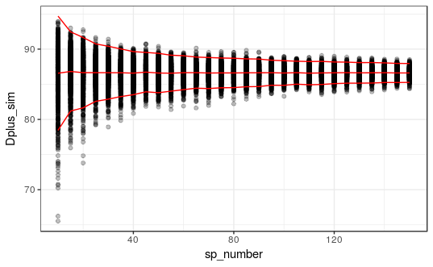

Same for Lambda:

`r`r ## transform the simulated Lambda data frame into a tibble, and clean & arrange it a little lambda.sim.long <- as_data_frame(lambda.sim.long) %>% mutate(sp_number = as.numeric(as.character(sp_number))) %>% arrange(sp_number) ## calculate the 95% confidence/tolerance intervals for each group (sp_number) lambda.sim.conf.int <- lambda.sim.long %>% group_by(sp_number) %>% mutate(lower = tolerance::normtol.int(Lambda_sim, alpha = 0.05, P = 0.95, side = 2)$`2-sided.lower`, upper = tolerance::normtol.int(Lambda_sim, alpha = 0.05, P = 0.95, side = 2)$`2-sided.upper`, average = mean(Lambda_sim))  
lambda.sim.conf.int <- lambda.sim.conf.int %>% distinct(sp_number, lower, upper, average) ## plot this, too ggplot(lambda.sim.long, aes(x = sp_number, y = Lambda_sim)) + geom_point(alpha = 0.25) + geom_line(aes(x = sp_number, y = lower), data = lambda.sim.conf.int, color = ) + geom_line(aes(x = sp_number, y = upper), data = lambda.sim.conf.int, color = ) + geom_line(aes(x = sp_number, y = average), data = lambda.sim.conf.int, color = )

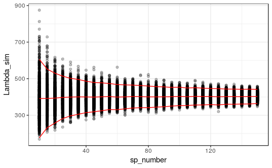

Save the theoretical simulated Delta+ & Lambda+ - it takes 10 min to repeat otherwise..

Now plot the observed values of D-plus in the sand dataset, and add these confidence limits.

`r`r s.l.dplus.sand <- bind_cols(S = tax.distinctness.sand$Species, Dplus = tax.distinctness.sand$Dplus, Lambda = tax.distinctness.sand$Lambda, station = zoo.abnd.sand$station) plot.dplus.sand <- ggplot(s.l.dplus.sand, aes(x = S, y = Dplus, color = station)) + scale_color_brewer(palette = 2, labels = paste0(, as.numeric(unique(s.l.dplus.sand$station)))) + geom_point(alpha = 0.75, size = 2) + xlim(0, 100) + labs(x = of species, y = expression(paste(Delta, +))) + text_size(text.x = rel(1.2), text.y = rel(1.2), legend.text = rel(1.1), title.x = rel(1.1), title.y = rel(1.1), legend.title = rel(1.1))

## add confidence/tolerance lines

(plot.dplus.sand <- plot.dplus.sand + geom_line(aes(x = sp_number, y = lower), data = dplus.sim.conf.int, color = 40, lwd = 0.3) + geom_line(aes(x = sp_number, y = upper), data = dplus.sim.conf.int, color = 40, lwd = 0.3) + geom_line(aes(x = sp_number, y = average), data = dplus.sim.conf.int, color = 40, lwd = 0.3) )

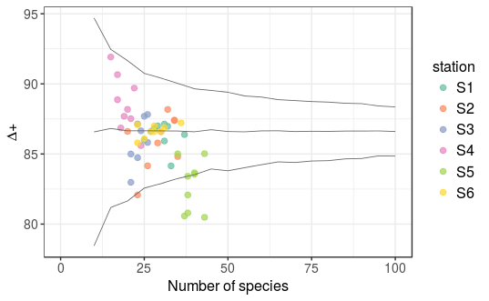

And now plot the observed Lambda values, with the theoretical (simulated) confidence intervals.

`r`r plot.lambda.sand <- ggplot(s.l.dplus.sand, aes(x = S, y = Lambda, color = station)) + scale_color_brewer(palette = 2, labels = paste0(, as.numeric(unique(s.l.dplus.sand$station)))) + geom_point(alpha = 0.75, size = 2) + xlim(0, 100) + labs(x = of species, y = expression(paste(Lambda, +))) + text_size(text.x = rel(1.2), text.y = rel(1.2), legend.text = rel(1.1), title.x = rel(1.1), title.y = rel(1.1), legend.title = rel(1.1)) ## add the confidence/tolerance intervals (plot.lambda.sand <- plot.lambda.sand + geom_line(aes(x = sp_number, y = lower), data = lambda.sim.conf.int, color = 40, lwd = 0.3) + geom_line(aes(x = sp_number, y = upper), data = lambda.sim.conf.int, color = 40, lwd = 0.3) + geom_line(aes(x = sp_number, y = average), data = lambda.sim.conf.int, color = 40, lwd = 0.3) )

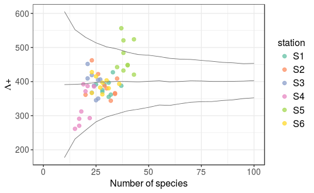

[output not shown]

`r`r ## get the legend from one of the plots, and put it at the bottom dplus.legend <- cowplot::get_legend(plot.dplus.sand + theme(legend.position = ))

```
Removed 10 rows containing missing values (geom_path).Removed 10 rows containing missing values (geom_path).Removed 10 rows containing missing values (geom_path).
```

`r`r (plot.dplus.l.combined.sand <- cowplot::plot_grid(plot.dplus.l.combined.sand, dplus.legend, ncol = 1, rel_heights = c(1, 0.2)) ) ## save & clean up cowplot::save_plot(here::here(figures.dir, _lambda_combined_sand.png), plot.dplus.l.combined.sand, base_aspect_ratio = 0.9, base_width = 5.5, dpi = 300)

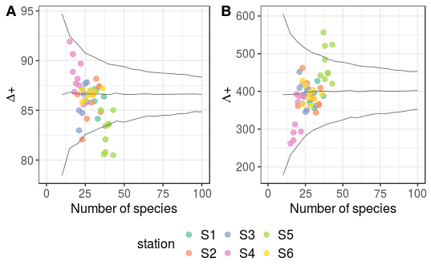

`r`r rm(dplus.legend)

Most of the samples fall within the theoretical 95% confidence limits, and near the average theoretical values of both taxonomic distinctness indices - therefore do not deviate from expected taxonomic breadth & structure. Exception: several samples from S5 - Agalina (+ 1 from Chukalya, but I guess it’s an anomaly) - lower Dplus & higher Lambda than expected - although not extremely so. This might suggest stressed communities where some senstitive higher taxa have disappeared. In the case of Agalina, it’s more likely due to **natural stress** - because the station is located next to a natural reef from which it probably receives inputs of organic matter and various detritus (also observed during sample processing). In any case, there are no major anthropogenic sources of pressure in the area.  
Note that half of the Sozopol (S4) samples have lower taxonomic spread than the average expected - that’s because of the extreme dominance of *C. gallina* in the community. Still within the limits, though, so not indicative of any disturbance - just a natural consequence of this particular community structure.

##### Graphical analyses

###### **Diversity profiles**

Diversity profiles are a graphical representation of the shape of the community. They show how the perceived diversity changes as the emphasis shifts from common to rare species - we can judge their respective contributions in the community composition.  
Not sure if I’ll use them in the thesis (most likely not), but I’m including the calculation and graphs here, because I think they’re neat and I like them.

`r`r div.profiles.sand <- diversity_profiles(zoo.abnd.sand %>% select(-c(station:replicate))) ## convert to long & add stations (manually, unfortunately) div.profiles.sand.long <- div.profiles.sand %>% gather(key = id, value = value, -q) %>% mutate(id = gsub(, \, id), station = case_when(id %in% as.character(1:9) ~ , id %in% as.character(10:18) ~ , id %in% as.character(19:27) ~ , id %in% as.character(28:35) ~ , id %in% as.character(36:45) ~ , id %in% as.character(46:54) ~ )) ## convert profile id and station to factors, and q to numeric (div.profiles.sand.long <- div.profiles.sand.long %>% mutate(station = factor(station, levels = levels(zoo.abnd.sand$station)), id = factor(id, levels = 1:54), q = as.numeric(q)) )

| q | id | value | station |
| --- | --- | --- | --- |
| 0.00 | 1 | 31.000000 | Kraimorie |
| 0.11 | 1 | 27.834592 | Kraimorie |
| 0.22 | 1 | 24.944247 | Kraimorie |
| 0.33 | 1 | 22.347356 | Kraimorie |
| 0.44 | 1 | 20.050670 | Kraimorie |
| 0.55 | 1 | 18.048834 | Kraimorie |
| 0.66 | 1 | 16.325708 | Kraimorie |
| 0.77 | 1 | 14.857074 | Kraimorie |
| 0.88 | 1 | 13.613958 | Kraimorie |
| 0.99 | 1 | 12.565808 | Kraimorie |

[output cut: 990 more lines]

Now plot them, just to see what they look like.

`r`r plot_div_profiles <- function(div.profiles, one.panel = TRUE) { ## plots the diversity profiles by sampling station. ## Arguments: div.profiles - diversity profiles as data frame/tibble (long). ## one.panel - should the profiles for each station be plotted in ## a single panel (for example when average profiles only), or in ## separate panels by station? Default - single panel.  
## Output: ggplot object. p <- ggplot(data = div.profiles, aes(x = q, y = value, group = id, colour = station)) + scale_color_brewer(palette = 2) + labs(x = parameter q, y = ) + scale_x_continuous(breaks = scales::pretty_breaks()) if(!one.panel) { # plot the profiles in separate panels by station p <- p + geom_line() +  
facet_wrap(~station) + theme(legend.position = ) } else { # increase the line width to make the lines more visible  
p <- p + geom_line(size = 0.7) }

return(p) } plot_div_profiles(div.profiles.sand.long, one.panel = FALSE)

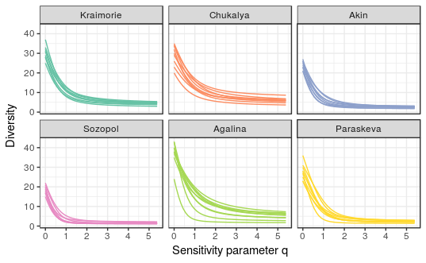

Generally, the higher the profile, the higher the diversity - here, Agalina (S5) & Chukalya (S2) have the highest profiles overall.  
It’s better, however, to calculate **weighted diversity profiles** by including a measure of similarity between species - for instance, taxonomic distance between them. This approach allows for a lot more meaningful ecological and biodiversity comparisons (Leinster & Cobbold, 2012). The weighted diversity profiles are a community’s “fingerprint”.

`r`r ## subset the large dist object (taxonomic distance b/n species) from before, to only the currently present species - in a very clumsy, very ugly way tax.dist.sand.current <- as.matrix(tax.dist.sand)[which(rownames(as.matrix(tax.dist.sand)) %in% colnames(zoo.abnd.sand)), which(colnames(as.matrix(tax.dist.sand)) %in% colnames(zoo.abnd.sand))] weighted.div.profiles.sand <- weighted_div_profiles(zoo.abnd.sand %>% select(-c(station:replicate)), tax.dist.sand.current, q = 50) ## convert to long, add stations & clean a little weighted.div.profiles.sand.long <- weighted.div.profiles.sand %>% gather(key = id, value = value, -q) %>% mutate(id = gsub(, \, id), station = case_when(id %in% as.character(1:9) ~ , id %in% as.character(10:18) ~ , id %in% as.character(19:27) ~ , id %in% as.character(28:35) ~ , id %in% as.character(36:45) ~ , id %in% as.character(46:54) ~ )) ## convert profile id and station to factors, and q to numeric (weighted.div.profiles.sand.long <- weighted.div.profiles.sand.long %>% mutate(station = factor(station, levels = levels(zoo.abnd.sand$station)), id = factor(id, levels = 1:54), q = as.numeric(q)) ) r plot_div_profiles(weighted.div.profiles.sand.long, one.panel = F)

| q | id | value | station |
| --- | --- | --- | --- |
| 0.00 | 1 | 5.932740 | Kraimorie |
| 0.11 | 1 | 5.640340 | Kraimorie |
| 0.22 | 1 | 5.366169 | Kraimorie |
| 0.33 | 1 | 5.111215 | Kraimorie |
| 0.44 | 1 | 4.875986 | Kraimorie |
| 0.55 | 1 | 4.660515 | Kraimorie |
| 0.66 | 1 | 4.464406 | Kraimorie |
| 0.77 | 1 | 4.286897 | Kraimorie |
| 0.88 | 1 | 4.126952 | Kraimorie |
| 0.99 | 1 | 3.983344 | Kraimorie |

[output cut: 990 more lines]

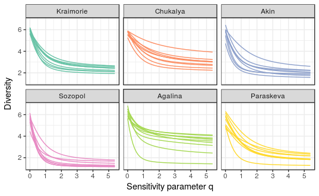

Now, it’s more clearly apparent: Chukalya & Agalina have the most diverse communities; then - Kraimorie, Akin & Paraskeva; and Sozopol has the lowest effective diversity. Agalina & Paraskeva also have several “atypical” samples with many rare species - whose profiles drop very sharply for 0 < q < 1.  
Let’s calculate the average diversity profiles by station, because these plots are very busy, and plot everything more cleanly.

`r`r (aver.weighted.div.profiles.sand <- weighted.div.profiles.sand.long %>% group_by(station, q) %>% summarise(value = mean(value)) )

| station | q | value |
| --- | --- | --- |
| Kraimorie | 0.00 | 5.933213 |
| Kraimorie | 0.11 | 5.491153 |
| Kraimorie | 0.22 | 5.092284 |
| Kraimorie | 0.33 | 4.737504 |
| Kraimorie | 0.44 | 4.425887 |
| Kraimorie | 0.55 | 4.155002 |
| Kraimorie | 0.66 | 3.921370 |
| Kraimorie | 0.77 | 3.720950 |
| Kraimorie | 0.88 | 3.549552 |
| Kraimorie | 0.99 | 3.403142 |

[output cut: 290 more lines]

`r`r ggplot(aver.weighted.div.profiles.sand, aes(x = q, y = value, colour = station)) + geom_line(lwd = 0.75) + scale_color_brewer(palette = 2, labels = paste0(, as.numeric(unique(aver.weighted.div.profiles.sand$station))))+ labs(x = parameter q, y = )

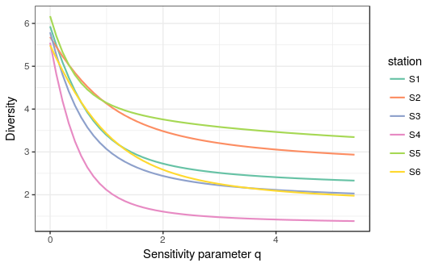

`r`r NA

Same conclusion as above.

###### **ABC curves**

These are cumulative k-dominance curves plotted from the species abundance distribution and the species biomass distribution -> y-axis scale: 0 to 100. Used to determine visually the level of disturbance of the communities. Under stable conditions, the competitive dominants in the communities are K-strategists - large-bodied, conservative species with long life-span, usually dominant in terms of biomass; when the communities suffer a perturbation, the smaller, opportunistic species are favored - small body size and short life-span, can be numerically significant, but rarely represent a large proportion of the biomass. Thus, under undisturbed conditions, the biomass curve is elevated over the abundance curve; under moderate disturbance, the biomass and the abundance curves are coincident and may cross each other one or several times; under severe disturbance, the abundance curve lies above the biomass curve throughout its length.  
First, we’ll calculate them on each replicate separately:

```r
(abc.sand <- abc(zoo.abnd.sand.long, zoo.biomass.sand.long,
                 abnd.val = sp_count, biomass.val = sp_biomass,
                 station, year, month, replicate)
)
```

| station | year | month | replicate | sp_rank | cum_abnd | cum_biomass |
| --- | --- | --- | --- | --- | --- | --- |
| Kraimorie | 2013 | 6 | a | 1 | 24.47917 | 57.53799 |
| Kraimorie | 2013 | 6 | a | 2 | 42.18750 | 87.52422 |
| Kraimorie | 2013 | 6 | a | 3 | 53.64583 | 95.83596 |
| Kraimorie | 2013 | 6 | a | 4 | 63.54167 | 96.74159 |
| Kraimorie | 2013 | 6 | a | 5 | 69.27083 | 97.63322 |
| Kraimorie | 2013 | 6 | a | 6 | 74.47917 | 98.02535 |
| Kraimorie | 2013 | 6 | a | 7 | 79.42708 | 98.34979 |
| Kraimorie | 2013 | 6 | a | 8 | 82.29167 | 98.61588 |
| Kraimorie | 2013 | 6 | a | 9 | 84.37500 | 98.85629 |
| Kraimorie | 2013 | 6 | a | 10 | 86.45833 | 99.05002 |

[output cut: 990 more lines]

| station | year | month | replicate | w |
| --- | --- | --- | --- | --- |
| Kraimorie | 2013 | 6 | a | 0.24048334 |
| Kraimorie | 2013 | 6 | b | 0.20071957 |
| Kraimorie | 2013 | 6 | c | 0.22855623 |
| Kraimorie | 2013 | 9 | a | 0.23745881 |
| Kraimorie | 2013 | 9 | b | 0.16019013 |
| Kraimorie | 2013 | 9 | c | 0.21204866 |
| Kraimorie | 2014 | 7 | a | 0.13716943 |
| Kraimorie | 2014 | 7 | b | 0.13600542 |
| Kraimorie | 2014 | 7 | c | 0.11822647 |
| Chukalya | 2013 | 6 | a | 0.11439391 |

[output cut: 44 more lines]

```r
## result is a list: 1) grouped df containing the curves (long), 2) summarized df with the W statistic per replicate - the distance between the 2 curves
```

We’ll plot W, because there are too many stations & replicates and the curves will be unreadable.

`r`r plot.w.sand <- ggplot(abc.sand[[2]], aes(x = station, y = w, colour = factor(year))) + geom_boxplot() + scale_color_viridis(option = , begin = 0.5, discrete = TRUE, name = \) + scale_x_discrete(name = , labels = paste0(, as.numeric(unique(abc.sand[[2]]$station)))) + ylab() + geom_hline(yintercept = 0) ## modify text size a little (plot.w.sand <- plot.w.sand + text_size(text.x = rel(1.2), text.y = rel(1.2), legend.text = rel(1), title.x = rel(1.1), title.y = rel(1.1)) ) ## and save this.. ggsave(here::here(figures.dir, _sand.png), plot.w.sand, width = 15, units = , dpi = 300)

```
Saving 15 x 8.78 cm image
```

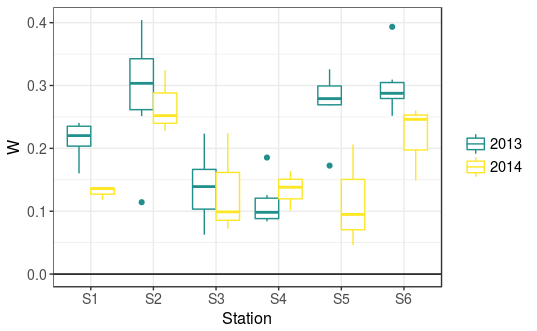

`r`r NA

W > 0 for all samples => the biomass curve is above the abundance curve, so none of the stations/replicates can be considered terribly disturbed. Still, W is pretty close to 0 (< 0.5 for all stations/years). The closer to 0 the statistic gets, the closer the 2 curves are; here, S5-Agalina comes closest, but still not too close. Nowhere is there complete dominance of one species in the biomass, perfectly even distribution of the abundance among species (W = 1, or tending towards it), nor the opposite (W = -1). In short, the structure of the communities is more or less even and normal, with variations characteristic of macrozoobenthic samples/communities. For S1, S2, S5, S6, W decreases somewhat between 2013-2014. There were less samples in 2014, but still, there might be some disturbance -> perhaps due to the heavy rains in the summer of 2014, esp. for S5-6 which were sampled immediately afterwards (although not really enough time for the communities to react, in my opinion - but will keep in mind just in case).

Let’s plot the summary ABC curves - per station and year. 2 rows (for the 2 years) + 6 columns (stations) in the plot - will put it in landscape format in the text.  
The summary curves will be calculated on **data averaged by year** - this way, there will hopefully be enough replication to reduce the over-dominance of large mollusks etc. in the biomass (they are rarely dominant in the abundance - more often represented by 1-2 individuals/sample).

```r
## summarize the abundance and biomass data per year (average)
(summary.abnd.sand <- zoo.abnd.sand.long %>%
   group_by(station, year, species) %>%
   summarize(mean_count = mean(sp_count))
)
```

| station | year | species | mean_count |
| --- | --- | --- | --- |
| Kraimorie | 2013 | Abra alba | 5.3333333 |
| Kraimorie | 2013 | Abra sp. | 0.0000000 |
| Kraimorie | 2013 | Acanthocardia tuberculata | 0.0000000 |
| Kraimorie | 2013 | Acari | 0.0000000 |
| Kraimorie | 2013 | Actiniaria | 0.0000000 |
| Kraimorie | 2013 | Alitta succinea | 1.3333333 |
| Kraimorie | 2013 | Ampelisca diadema | 2.8333333 |
| Kraimorie | 2013 | Amphibalanus improvisus | 1.0000000 |
| Kraimorie | 2013 | Amphipoda | 0.0000000 |
| Kraimorie | 2013 | Amphitritides gracilis | 0.0000000 |

[output cut: 990 more lines]

```r
(summary.biomass.sand <- zoo.biomass.sand.long %>%
   group_by(station, year, species) %>%
   summarize(mean_biomass = mean(sp_biomass))
)
```

| station | year | species | mean_biomass |
| --- | --- | --- | --- |
| Kraimorie | 2013 | Abra alba | 1.761667e-02 |
| Kraimorie | 2013 | Abra sp. | 0.000000e+00 |
| Kraimorie | 2013 | Acanthocardia tuberculata | 0.000000e+00 |
| Kraimorie | 2013 | Acari | 0.000000e+00 |
| Kraimorie | 2013 | Actiniaria | 0.000000e+00 |
| Kraimorie | 2013 | Alitta succinea | 1.016667e-03 |
| Kraimorie | 2013 | Ampelisca diadema | 4.833333e-04 |
| Kraimorie | 2013 | Amphibalanus improvisus | 2.133333e-03 |
| Kraimorie | 2013 | Amphipoda | 0.000000e+00 |
| Kraimorie | 2013 | Amphitritides gracilis | 0.000000e+00 |

[output cut: 990 more lines]

Now calculate the summary ABC for 2013 and 2014 for the sand stations.

```r
(abc.summary.sand <- abc(summary.abnd.sand, summary.biomass.sand,
                         abnd.val = mean_count, biomass.val = mean_biomass,
                         station, year)
)
```

| station | year | sp_rank | cum_abnd | cum_biomass |
| --- | --- | --- | --- | --- |
| Kraimorie | 2013 | 1 | 28.07692 | 71.02412 |
| Kraimorie | 2013 | 2 | 50.04808 | 87.36364 |
| Kraimorie | 2013 | 3 | 60.38462 | 92.50465 |
| Kraimorie | 2013 | 4 | 66.58654 | 94.51092 |
| Kraimorie | 2013 | 5 | 72.01923 | 95.85524 |
| Kraimorie | 2013 | 6 | 76.73077 | 97.01854 |
| Kraimorie | 2013 | 7 | 80.72115 | 98.12294 |
| Kraimorie | 2013 | 8 | 82.83654 | 98.46541 |
| Kraimorie | 2013 | 9 | 84.37500 | 98.74060 |
| Kraimorie | 2013 | 10 | 85.91346 | 98.97623 |

[output cut: 990 more lines]

| station | year | w |
| --- | --- | --- |
| Kraimorie | 2013 | 0.15752339 |
| Kraimorie | 2014 | 0.08240380 |
| Chukalya | 2013 | 0.21950537 |
| Chukalya | 2014 | 0.19505714 |
| Akin | 2013 | 0.06853273 |
| Akin | 2014 | 0.08945998 |
| Sozopol | 2013 | 0.06844111 |
| Sozopol | 2014 | 0.10991490 |
| Agalina | 2013 | 0.16503316 |
| Agalina | 2014 | 0.05698750 |

[output cut: 2 more lines]

```
NA
```

All good, let’s plot these!  
Very often, the curves approach a cumulative frequency of 100 % for a large part of their length, esp. in highly dominated communities - often after the first 2-3 top-ranked species, making the forms of the abundance and biomass curves difficult to distinguish. We can transform the y-axis so that the cumulative values are closer to linearity - e.g. using a modified logistic transformation (Clarke & Warwick 2001).

`r`r ## reshape the data for easier plotting - and to have a legend.. abc.summary.sand.long <- abc.summary.sand[[1]] %>% gather(key = variable, value = value, -c(station:sp_rank)) %>% mutate(variable = case_when(variable == _abnd ~ , variable == _biomass ~ )) ## make named character vector for the custom station labels  
stations.sand <- paste0(, as.numeric(unique(abc.summary.sand[[1]]$station))) names(stations.sand) <- as.character(unique(abc.summary.sand[[1]]$station)) ## plot plot.summary.abc.sand <- ggplot(abc.summary.sand.long, aes(x = sp_rank, y = value, colour = variable)) + geom_line() + # apply axis transformations scale_x_log10() + coord_trans(y = _logistic) + # curve colours and legend scale_colour_manual(values = c(, ), name = \) + theme(legend.position = ) + # facets & labels facet_grid(year ~ station, labeller = labeller(station = as_labeller(stations.sand))) + labs(x = rank (log), y = %) ## modify text size a little (plot.summary.abc.sand <- plot.summary.abc.sand + text_size(text.x = rel(1.2), text.y = rel(1.2), legend.text = rel(1), title.x = rel(1.1), title.y = rel(1.1), strip.x = rel(1.1), strip.y = rel(1.1)) ) ## and save this - huge, because I think it will be displayed best as a whole-page graph.. ggsave(here::here(figures.dir, _abc_sand.png), plot.summary.abc.sand, width = 25, height = 15, units = , dpi = 300)

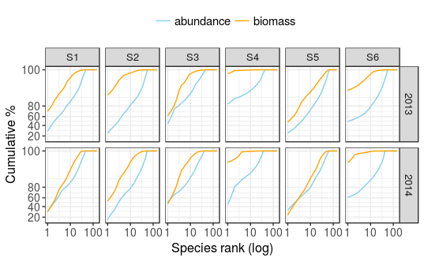

`r`r rm(abc.summary.sand.long)

General conclusions still the same: overall, biomass curve above abundance curve everywhere; slightly worse condition of the communities in 2014 (curves closer to one another for more stations); no change at some stations (S3-Akin, S4-Sozopol, S6-Paraskeva). Otherwise, results seem to follow gradient more or less - curves closer to one another at inner stations, wider apart at outer ones; exception - S5-Agalina - arguably the worst - but again, probably naturally “stressed” - no major pressure sources nearby..

Finally, make a combined plot of W and ABC to use in the text; there are already a million plots so I need to conserve space as much as possible..

`r`r (plot.abc.w.combined.sand <- cowplot::plot_grid(plot.summary.abc.sand, plot.w.sand + theme(legend.position = ), labels = c(, ), ncol = 2, rel_widths = c(2,1)) ) ## save & clean up cowplot::save_plot(here::here(figures.dir, _w_combined_sand.png), plot.abc.w.combined.sand, base_width = 10, base_height = 6, dpi = 300)

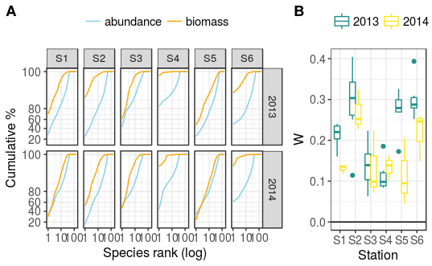

###### **Partial dominance curves**

Used in order to avoid problems of over-dominance of species affecting the curves and their interpretation. Partial dominance curves compute the dominance of the second ranked species over the remainder, ignoring the first-ranked species, and so on with the remaining species. Thus, earlier values do not affect later points on the curve. Partial dominance ABC curves for undisturbed macrobenthic communities have the biomass curve over the abundance curve (mostly) throughout its length. The abundance curve is smoother; the biomass curve shows a slight and steady decline before its inevitable final rise. Under polluted conditions, there is still a change in position of partial dominance curves, and the abundance curve is much more “ragged”: the implication is that the disturbance is affecting the whole suite of species in the community (Clarke & Warwick 2001).

`r`r ## will be calculated directly on the summarized abundance/biomass data (pd.summary.sand <- partial_dominance_curves(summary.abnd.sand, summary.biomass.sand, abnd.val = mean_count, biomass.val = mean_biomass, station, year) )

| station | year | sp_rank | partial_abnd | partial_biomass |
| --- | --- | --- | --- | --- |
| Kraimorie | 2013 | 1 | 28.076923 | 71.024117 |
| Kraimorie | 2013 | 2 | 30.548128 | 56.390090 |
| Kraimorie | 2013 | 3 | 20.692974 | 40.684281 |
| Kraimorie | 2013 | 4 | 15.655340 | 26.766866 |
| Kraimorie | 2013 | 5 | 16.258993 | 24.490835 |
| Kraimorie | 2013 | 6 | 16.838488 | 28.066808 |
| Kraimorie | 2013 | 7 | 17.148760 | 37.042111 |
| Kraimorie | 2013 | 8 | 10.972569 | 18.245333 |
| Kraimorie | 2013 | 9 | 8.963585 | 17.932194 |
| Kraimorie | 2013 | 10 | 9.846154 | 18.709457 |

[output cut: 580 more lines]

Let’s see what this looks like (and if it’s any improvement over the regular ABS curves)..

`r`r ## reshape the data as before.. pd.summary.sand.long <- pd.summary.sand %>% gather(key = variable, value = value, -c(station:sp_rank)) %>% mutate(variable = case_when(variable == _abnd ~ , variable == _biomass ~ )) ## plot plot.pd.sand <- ggplot(pd.summary.sand.long, aes(x = sp_rank, y = value, colour = variable)) + geom_line() + # apply axis transformations scale_x_log10() + # curve colours and legend scale_colour_manual(values = c(, ), name = \) + theme(legend.position = ) + # facets & labels facet_grid(year ~ station, labeller = labeller(station = as_labeller(stations.sand))) + labs(x = rank (log), y = %) ## modify text size a little (plot.pd.sand <- plot.pd.sand + text_size(text.x = rel(1.2), text.y = rel(1.2), title.x = rel(1.1), title.y = rel(1.1), strip.x = rel(1.1), strip.y = rel(1.1)) ) ## save, just in case, although I don’t much see the point in using ALL of them, when they’re showing basically the same thing.. ggsave(here::here(figures.dir, _pd_sand.png), plot.pd.sand, width = 25, height = 15, units = , dpi = 300)

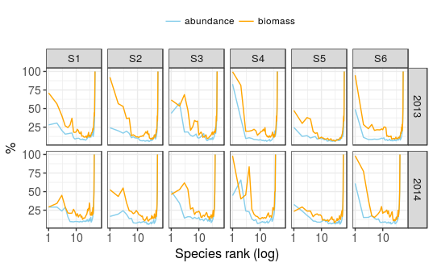

`r`r rm(pd.summary.sand.long)

More or less the same pattern.. Slight apparent worsening of the community structure in 2014; S5-Agalina - the most disturbed (curves instersect several times and are closest together, as well as somewhat ragged). Interesting - S4-Sozopol (and S6-Paraskeva, a little) - the dominance of the clam *C. gallina* is very clear from the curves - sharp drop of the biomass & abundance after the first-ranked species.

#### Macrozoobenthic communities in the seagrasses of Burgas Bay (2013-2014)

Import the abundance & biomass data - again, from the cleaned & saved datasets, to avoid (most of) the cleaning steps.

```r
## dimensions should be 32 x 205 (5 metadata + 200 species columns); all species columns should be numeric.
zoo.abnd.zostera <- read_csv(here::here(save.dir, "abnd_zostera_orig_clean.csv"))

## same for biomass; same expected structure as the abundance
zoo.biomass.zostera <- read_csv(here::here(save.dir, "biomass_zostera_orig_clean.csv"))
```

Convert columns to the proper type, arrange the datasets by station, etc.

```r
zoo.abnd.zostera <- zoo.abnd.zostera %>%
  mutate(station = factor(station, levels = c("Poda", "Otmanli", "Vromos", "Gradina", "Ropotamo"))) %>%
  arrange(station, year, month)

zoo.biomass.zostera <- zoo.biomass.zostera %>%
  mutate(station = factor(station, levels = c("Poda", "Otmanli", "Vromos", "Gradina", "Ropotamo"))) %>%
  arrange(station, year, month)
```

Remove all species not present in the datasets (= all-0 columns).

```r
## result should have dimensions 32 x 99 (94 species + 5 metadata columns)
zoo.abnd.zostera <- zoo.abnd.zostera %>%
  gather(key = species, value = sp_count, -c(station:replicate)) %>%
  group_by(species) %>%
  filter(sp_count > 0) %>%
  spread(species, sp_count, fill = 0) %>%
  arrange(station, year, month)

zoo.biomass.zostera <- zoo.biomass.zostera %>%
  gather(key = species, value = sp_biomass, -c(station:replicate)) %>%
  group_by(species) %>%
  filter(sp_biomass > 0) %>%
  spread(species, sp_biomass, fill = 0) %>%
  arrange(station, year, month)
```

Transform to long format.

```r
zoo.abnd.zostera.long <- zoo.abnd.zostera %>%
  gather(key = species, value = sp_count, -c(station:replicate))

zoo.biomass.zostera.long <- zoo.biomass.zostera %>%
  gather(key = species, value = sp_biomass, -c(station:replicate))
```

##### Alpha diversity indices

`r`r ## uses custom function for convenience - has to be imported first! alpha.div.zostera <- zoo.abnd.zostera %>% select(-c(station:replicate)) %>% alpha_diversity() ## add the metadata columns (row order is not changed, so possible) (alpha.div.zostera <- bind_cols(zoo.abnd.zostera %>% select(station:replicate), alpha.div.zostera) )

| station | month | year | habitat | replicate | sp_richness | shannon_h | evenness_j | h_effective |
| --- | --- | --- | --- | --- | --- | --- | --- | --- |
| Poda | 6 | 2013 | Z | a | 25 | 2.083198 | 0.6471817 | 8.030105 |
| Poda | 6 | 2013 | Z | b | 25 | 2.176458 | 0.6761547 | 8.815028 |
| Poda | 6 | 2013 | Z | c | 19 | 1.858955 | 0.6313442 | 6.417024 |
| Poda | 6 | 2013 | Z | d | 22 | 2.089014 | 0.6758283 | 8.076947 |
| Poda | 7 | 2014 | Z | a | 19 | 2.161118 | 0.7339659 | 8.680836 |
| Poda | 7 | 2014 | Z | b | 22 | 1.617053 | 0.5231417 | 5.038222 |
| Poda | 7 | 2014 | Z | c | 26 | 1.937194 | 0.5945784 | 6.939250 |
| Poda | 7 | 2014 | Z | d | 21 | 2.134673 | 0.7011520 | 8.454282 |
| Otmanli | 6 | 2013 | Z | a | 19 | 2.223735 | 0.7552321 | 9.241782 |
| Otmanli | 6 | 2013 | Z | b | 28 | 2.125901 | 0.6379862 | 8.380441 |

[output cut: 22 more lines]

Summarize these diversity indices by station & year.

`r`r ## STILL haven’t learned how to use the functions from package sjPlot for printing pretty (and easy!) tables…  
alpha.div.zostera %>% group_by(station, year) %>% summarise(h_mean = mean(shannon_h), h_sd = sd(shannon_h), j_mean = mean(evenness_j), j_sd = sd(evenness_j), h_eff_mean = mean(h_effective), h_eff_sd = sd(h_effective) )

| station | year | h_mean | h_sd | j_mean | j_sd | h_eff_mean | h_eff_sd |
| --- | --- | --- | --- | --- | --- | --- | --- |
| Poda | 2013 | 2.051906 | 0.13552323 | 0.6576272 | 0.02216943 | 7.834776 | 1.0112227 |
| Poda | 2014 | 1.962509 | 0.25104216 | 0.6382095 | 0.09708300 | 7.278147 | 1.6815614 |
| Otmanli | 2013 | 2.285342 | 0.20480663 | 0.7100833 | 0.05578310 | 9.993762 | 2.2188803 |
| Otmanli | 2014 | 2.169409 | 0.10317118 | 0.6591192 | 0.03898423 | 8.788450 | 0.9197032 |
| Vromos | 2014 | 1.831036 | 0.07488171 | 0.6345061 | 0.03064159 | 6.253379 | 0.4628598 |
| Gradina | 2013 | 1.776515 | 0.31813952 | 0.5196976 | 0.09813821 | 6.143589 | 2.0268430 |
| Gradina | 2014 | 2.096437 | 0.37260337 | 0.6299569 | 0.11658068 | 8.539753 | 2.8456098 |
| Ropotamo | 2013 | 2.272349 | 0.16504407 | 0.6555533 | 0.03645002 | 9.805125 | 1.6993370 |

2. Species accumulation curves - see how species are added when the number of samples (sites) increases. Usually used to see if the sampling effort is adequate & captures most of the diversity in the study area.

`r`r sac.zostera <- specaccum(select(zoo.abnd.zostera, -c(station:replicate))) ## extract data (temporarily) to plot in ggplot sac.data.zostera <- as_data_frame(sac.zostera[c(, , )]) ## plot & save (plot.sac.zostera <- ggplot(sac.data.zostera) + geom_line(aes(x = sites, y = richness), colour = 40) + geom_ribbon(aes(x = sites, ymin = richness - sd, ymax = richness + sd), alpha = 0.3, fill = ) + ## add a line with slope 1 tangent to the accumulation curve - unfortunately, by eye, trial & error..  
geom_abline(aes(intercept = 65, slope = 1), colour = , lty = 3) + labs(x = , y = number of species) + text_size(text.x = rel(1.2), text.y = rel(1.2), title.x = rel(1.05), title.y = rel(1.05)) ) ## save & clean up ggsave(here(figures.dir, _zostera.png), plot.sac.zostera, width = 15, units = , dpi = 300)

```
Saving 15 x 8.86 cm image
```

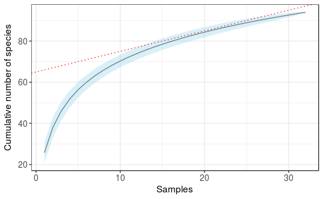

`r`r rm(sac.data.zostera)

Again, about 20 (maybe a little more) samples seem to be enough to capture most of the biodiversity in the study area (in terms of species richness) - this is where the curve starts to smooth out (slope < 1). In my seagrass dataset, there are 32 samples in total - let’s say that’s about enough..  
NB IF this method is applied correctly, since the samples are not independent but in fact represent replicates at each station..

##### Species pool

The species pool is the total extrapolated number of species in the study area (various estimates used here). Used to estimate the number of **unobserved species**. The functions assume that the number of unobserved species is related to he number of rare species (= seen only once or twice).

`r`r ## this function is based on incidences in sample sites - presence/absence data; gives a single estimate for a collection of sample sites specpool(select(zoo.abnd.zostera, -c(station:replicate)), pool = zoo.abnd.zostera$station, smallsample = TRUE) r ## this function is quantitative - based on abundances on single sample site estimateR(select(zoo.abnd.zostera, -c(station:replicate)))

```
              [,1]      [,2]      [,3]      [,4]      [,5]      [,6]
S.obs    25.000000 25.000000 19.000000 22.000000 19.000000 22.000000
S.chao1  32.000000 30.250000 19.600000 36.000000 19.500000 31.333333
se.chao1  7.096984  5.361358  1.182624 13.162447  1.024626  8.835210
S.ACE    31.622984 30.191773 20.769849 29.512298 20.787549 29.051915
se.ACE    2.837288  2.516131  2.088840  2.647512  1.976620  2.507704
              [,7]      [,8]       [,9]     [,10]     [,11]     [,12]
S.obs    26.000000 21.000000 19.0000000 28.000000 31.000000 24.000000
S.chao1  38.000000 30.333333 19.3333333 43.166667 34.000000 31.500000
se.chao1 10.744950  8.834034  0.9207647 10.847755  3.414330  6.343828
S.ACE    34.409882 31.115071 19.9875053 54.912162 35.412890 38.168975
se.ACE    2.814553  3.037235  2.1588768  3.927622  2.931608  3.036397
             [,13]     [,14]     [,15]     [,16]     [,17]     [,18]
S.obs    26.000000 25.000000 27.000000 30.000000 18.000000 14.000000
S.chao1  31.250000 28.500000 36.166667 43.000000 23.000000 15.000000
se.chao1  5.361830  3.656352  7.372888  9.250701  5.514802  1.805342
S.ACE    31.403845 30.450421 42.956296 54.289962 23.104307 16.375000
se.ACE    2.554354  2.592238  3.587764  4.679007  2.199110  1.966560
             [,19]     [,20]     [,21]     [,22]     [,23]     [,24]
S.obs    22.000000 19.000000 35.000000 30.000000 28.000000 30.000000
S.chao1  44.500000 19.600000 54.500000 36.000000 39.000000 38.666667
se.chao1 19.246789  1.182624 14.730063  5.383069  8.865143  6.410052
S.ACE    42.312510 21.033626 52.348482 39.001511 44.998123 45.717542
se.ACE    3.873272  2.194306  4.492371  3.329637  3.916736  3.619842
             [,25]     [,26]     [,27]     [,28]      [,29]     [,30]
S.obs    27.000000 30.000000 28.000000 27.000000 31.0000000 30.000000
S.chao1  43.500000 41.000000 31.500000 27.857143 31.0769231 31.000000
se.chao1 12.884371  8.865912  3.656974  1.393243  0.3221019  1.811948
S.ACE    46.398305 43.297797 33.680178 29.822816 32.0315125 31.251453
se.ACE    3.689013  3.262781  2.757585  2.633059  2.6619472  2.699493
             [,31]     [,32]
S.obs    32.000000 35.000000
S.chao1  43.000000 41.428571
se.chao1  8.866608  5.462874
S.ACE    46.103662 42.859390
se.ACE    3.669849  3.180521
```

|  | Species | chao | chao.se | jack1 | jack1.se | jack2 | boot | boot.se | n |
| --- | --- | --- | --- | --- | --- | --- | --- | --- | --- |
| Poda | 55 | 65.12500 | 6.342617 | 70.75 | 6.597822 | 75.25000 | 62.73836 | 3.874650 | 8 |
| Otmanli | 55 | 69.29167 | 10.329146 | 67.25 | 5.144779 | 73.89286 | 60.58107 | 2.908033 | 8 |
| Vromos | 30 | 40.80000 | 8.544472 | 39.00 | 5.809475 | 43.33333 | 34.11328 | 3.038628 | 4 |
| Gradina | 69 | 82.23438 | 7.485077 | 88.25 | 7.784199 | 94.46429 | 78.31775 | 4.294607 | 8 |
| Ropotamo | 46 | 48.40000 | 2.419917 | 52.00 | 5.196152 | 52.66667 | 49.20312 | 3.445693 | 4 |

Now let’s do it for the whole dataset.

`r`r specpool(select(zoo.abnd.zostera, -c(station:replicate)), smallsample = TRUE)

|  | Species | chao | chao.se | jack1 | jack1.se | jack2 | boot | boot.se | n |
| --- | --- | --- | --- | --- | --- | --- | --- | --- | --- |
| All | 94 | 115.3609 | 12.40573 | 114.3438 | 5.768059 | 124.9587 | 103.3214 | 3.048434 | 32 |

##### Taxonomic distance & diversity

No need to redo all the master list/simulated community calculations as before - they’re valid for the seagrasses, too.  
Calculate the **taxonomic distance** for the seagrass zoobenthic communities.

```r
## we'll use the same taxonomic distance for the master species list as before

## calculate the taxonomic distinctness indices for the abundance dataset
(tax.distinctness.zostera <- taxondive(select(zoo.abnd.zostera, -c(station:replicate)), tax.dist.all)
)
```

```
dimensions do not match between 'comm' and 'dis'
matched 'dis' labels by 'comm' names
```

```
         Species   Delta  Delta* Lambda+  Delta+ S Delta+
          25.000  54.940  69.482 399.283  87.837   2195.9
          25.000  62.111  79.221 376.731  87.598   2190.0
          19.000  60.288  79.750 406.726  86.794   1649.1
          22.000  62.767  78.966 357.004  88.956   1957.0
          19.000  74.235  91.278 362.651  86.086   1635.6
          22.000  56.045  92.124 441.517  83.291   1832.4
          26.000  61.380  89.883 325.013  87.651   2278.9
          21.000  71.351  90.376 354.398  88.270   1853.7
          19.000  64.989  76.366 311.235  89.602   1702.4
          28.000  62.028  76.068 341.923  87.768   2457.5
          31.000  75.983  84.917 383.759  86.713   2688.1
          24.000  62.037  73.844 363.050  87.080   2089.9
          26.000  69.956  88.586 348.863  87.093   2264.4
          25.000  74.115  89.625 347.323  87.386   2184.7
          27.000  69.275  89.883 416.831  85.727   2314.6
          30.000  71.233  87.846 376.560  86.692   2600.8
          18.000  67.448  86.709 369.930  89.294   1607.3
          14.000  64.897  87.862 447.940  84.341   1180.8
          22.000  66.659  85.159 430.593  86.561   1904.3
          19.000  65.107  84.229 429.483  87.150   1655.9
          35.000  66.128  91.016 352.850  87.739   3070.9
          30.000  53.263  86.616 330.489  87.884   2636.5
          28.000  72.279  87.939 338.106  88.554   2479.5
          30.000  49.672  88.006 317.835  89.160   2674.8
          27.000  77.686  91.815 320.662  88.768   2396.7
          30.000  70.530  90.584 423.914  86.706   2601.2
          28.000  54.576  91.514 380.932  87.695   2455.5
          27.000  77.770  89.211 347.961  87.878   2372.7
          31.000  66.679  80.595 416.255  86.627   2685.4
          30.000  65.246  82.062 419.450  86.841   2605.2
          32.000  69.949  86.194 346.447  88.392   2828.5
          35.000  73.969  84.044 401.530  86.820   3038.7
Expected          78.402  77.817          86.254
```

```r
## get the summary - includes a significance test on Delta+
summary(tax.distinctness.zostera)
```

```
           Delta  Delta*  Delta+ sd(Delta+) z(Delta+) Pr(>|z|)
         54.9400 69.4816 87.8370     2.2504    0.7037   0.4817
         62.1113 79.2210 87.5984     2.2504    0.5976   0.5501
         60.2882 79.7505 86.7939     2.7650    0.1954   0.8450
         62.7669 78.9665 88.9564     2.4795    1.0901   0.2757
         74.2355 91.2780 86.0863     2.7650   -0.0605   0.9518
         56.0454 92.1237 83.2907     2.4795   -1.1949   0.2321
         61.3805 89.8830 87.6508     2.1833    0.6400   0.5222
         71.3512 90.3761 88.2695     2.5673    0.7853   0.4323
         64.9890 76.3660 89.6017     2.7650    1.2109   0.2259
         62.0282 76.0684 87.7676     2.0603    0.7349   0.4624
         75.9826 84.9166 86.7129     1.8986    0.2420   0.8088
         62.0371 73.8439 87.0797     2.3218    0.3559   0.7219
         69.9563 88.5863 87.0934     2.1833    0.3847   0.7005
         74.1154 89.6250 87.3863     2.2504    0.5034   0.6147
         69.2747 89.8831 85.7266     2.1201   -0.2485   0.8037
         71.2334 87.8457 86.6922     1.9498    0.2250   0.8220
         67.4477 86.7087 89.2939     2.8773    1.0567   0.2907
         64.8970 87.8620 84.3413     3.4589   -0.5528   0.5804
         66.6592 85.1586 86.5612     2.4795    0.1241   0.9013
         65.1071 84.2295 87.1505     2.7650    0.3244   0.7456
         66.1285 91.0157 87.7387     1.7151    0.8659   0.3865
         53.2631 86.6163 87.8837     1.9498    0.8361   0.4031
         72.2788 87.9392 88.5542     2.0603    1.1167   0.2641
         49.6717 88.0056 89.1601     1.9498    1.4906   0.1361
         77.6861 91.8149 88.7685     2.1201    1.1862   0.2355
         70.5303 90.5839 86.7055     1.9498    0.2318   0.8167
         54.5757 91.5135 87.6950     2.0603    0.6996   0.4842
         77.7704 89.2112 87.8775     2.1201    0.7660   0.4437
         66.6795 80.5949 86.6268     1.8986    0.1966   0.8442
         65.2463 82.0617 86.8407     1.9498    0.3011   0.7633
         69.9491 86.1936 88.3915     1.8497    1.1559   0.2477
         73.9685 84.0436 86.8202     1.7151    0.3304   0.7411
Expected 78.4020 77.8174 86.2535
```

Huh, not even a single significant p-value.. How sweet.  
Now plot the real, observed values of D-plus in the seagrass dataset, and add these confidence limits.

`r`r s.l.dplus.zostera <- bind_cols(S = tax.distinctness.zostera$Species, Dplus = tax.distinctness.zostera$Dplus, Lambda = tax.distinctness.zostera$Lambda, station = zoo.abnd.zostera$station) plot.dplus.zostera <- ggplot(s.l.dplus.zostera, aes(x = S, y = Dplus, color = station)) + scale_color_brewer(palette = 2, labels = paste0(, as.numeric(unique(s.l.dplus.zostera$station)))) + geom_point(alpha = 0.85, size = 2) + xlim(0, 100) + labs(x = of species, y = expression(paste(Delta, +))) + text_size(text.x = rel(1.2), text.y = rel(1.2), legend.text = rel(1.1), title.x = rel(1.1), title.y = rel(1.1), legend.title = rel(1.1))

## add confidence/tolerance lines

(plot.dplus.zostera <- plot.dplus.zostera + geom_line(aes(x = sp_number, y = lower), data = dplus.sim.conf.int, color = 40, lwd = 0.3) + geom_line(aes(x = sp_number, y = upper), data = dplus.sim.conf.int, color = 40, lwd = 0.3) + geom_line(aes(x = sp_number, y = average), data = dplus.sim.conf.int, color = 40, lwd = 0.3) )

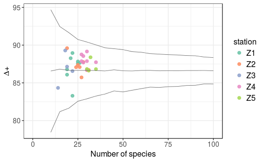

And now plot the observed Lambda values, with the theoretical (simulated) confidence intervals.

`r`r plot.lambda.zostera <- ggplot(s.l.dplus.zostera, aes(x = S, y = Lambda, color = station)) + scale_color_brewer(palette = 2, labels = paste0(, as.numeric(unique(s.l.dplus.zostera$station)))) + geom_point(alpha = 0.85, size = 2) + xlim(0, 100) + labs(x = of species, y = expression(paste(Lambda, +))) + text_size(text.x = rel(1.2), text.y = rel(1.2), legend.text = rel(1.1), title.x = rel(1.1), title.y = rel(1.1), legend.title = rel(1.1)) ## add the confidence/tolerance intervals (plot.lambda.zostera <- plot.lambda.zostera + geom_line(aes(x = sp_number, y = lower), data = lambda.sim.conf.int, color = 40, lwd = 0.3) + geom_line(aes(x = sp_number, y = upper), data = lambda.sim.conf.int, color = 40, lwd = 0.3) + geom_line(aes(x = sp_number, y = average), data = lambda.sim.conf.int, color = 40, lwd = 0.3) )

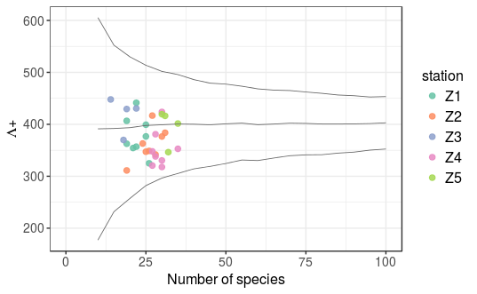

[output not shown]

`r`r ## get the legend from one of the plots, and put it at the bottom dplus.legend <- cowplot::get_legend(plot.dplus.zostera + theme(legend.position = ))

```
Removed 10 rows containing missing values (geom_path).Removed 10 rows containing missing values (geom_path).Removed 10 rows containing missing values (geom_path).
```

`r`r (plot.dplus.l.combined.zostera <- cowplot::plot_grid(plot.dplus.l.combined.zostera, dplus.legend, ncol = 1, rel_heights = c(1, 0.2)) ) ## save & clean up cowplot::save_plot(here::here(figures.dir, _lambda_combined_zostera.png), plot.dplus.l.combined.zostera, base_aspect_ratio = 0.9, base_width = 5.5, dpi = 300)

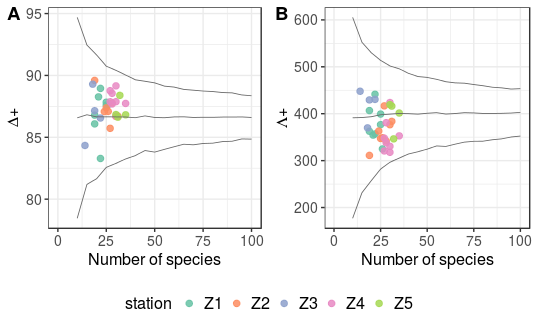

`r`r rm(dplus.legend)

All of the samples fall within the theoretical 95% confidence limits, and near the average theoretical values of both taxonomic distinctness indices - therefore do not deviate from expected taxonomic breadth & structure. This confirms the lack of significant values in the z-test above (-> no difference in observed taxonomic structure than expected).

##### Graphical analyses

###### **Diversity profiles**

Included more for the sake of completeness than for any other reason.

`r`r div.profiles.zostera <- diversity_profiles(zoo.abnd.zostera %>% select(-c(station:replicate))) ## convert to long & add stations (manually, unfortunately) div.profiles.zostera.long <- div.profiles.zostera %>% gather(key = id, value = value, -q) %>% mutate(id = gsub(, \, id), station = case_when(id %in% as.character(1:8) ~ , id %in% as.character(9:16) ~ , id %in% as.character(17:20) ~ , id %in% as.character(21:28) ~ , id %in% as.character(29:32) ~ )) ## convert profile id and station to factors, and q to numeric (div.profiles.zostera.long <- div.profiles.zostera.long %>% mutate(station = factor(station, levels = levels(zoo.abnd.zostera$station)), id = factor(id, levels = 1:54), q = as.numeric(q)) )

| q | id | value | station |
| --- | --- | --- | --- |
| 0.00 | 1 | 25.000000 | Poda |
| 0.11 | 1 | 21.826063 | Poda |
| 0.22 | 1 | 19.013848 | Poda |
| 0.33 | 1 | 16.561930 | Poda |
| 0.44 | 1 | 14.457164 | Poda |
| 0.55 | 1 | 12.675806 | Poda |
| 0.66 | 1 | 11.186042 | Poda |
| 0.77 | 1 | 9.951385 | Poda |
| 0.88 | 1 | 8.934141 | Poda |
| 0.99 | 1 | 8.098258 | Poda |

[output cut: 990 more lines]

Now plot them, just to see what they look like.

`r`r plot_div_profiles(div.profiles.zostera.long, one.panel = FALSE)

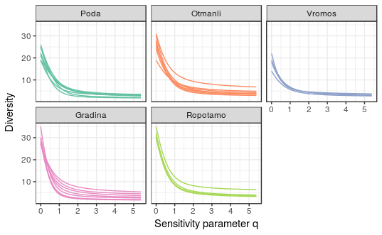

Here, Gradina (Z4), Otmanli (Z2) & Ropotamo (Z5) seem to have the highest profiles (= highest diversity) overall.  
Calculate the **weighted diversity profiles** by including a measure of similarity between species - here, again, the taxonomic distance between them.

`r`r ## subset the large dist object (taxonomic distance b/n species) from before, to only the currently present species - in a very clumsy, very ugly way tax.dist.zostera.current <- as.matrix(tax.dist.sand)[which(rownames(as.matrix(tax.dist.sand)) %in% colnames(zoo.abnd.zostera)), which(colnames(as.matrix(tax.dist.sand)) %in% colnames(zoo.abnd.zostera))] weighted.div.profiles.zostera <- weighted_div_profiles(zoo.abnd.zostera %>% select(-c(station:replicate)), tax.dist.zostera.current, q = 50) ## convert to long, add stations & clean a little (as before) weighted.div.profiles.zostera.long <- weighted.div.profiles.zostera %>% gather(key = id, value = value, -q) %>% mutate(id = gsub(, \, id), station = case_when(id %in% as.character(1:8) ~ , id %in% as.character(9:16) ~ , id %in% as.character(17:20) ~ , id %in% as.character(21:28) ~ , id %in% as.character(29:32) ~ )) ## convert profile id and station to factors, and q to numeric (weighted.div.profiles.zostera.long <- weighted.div.profiles.zostera.long %>% mutate(station = factor(station, levels = levels(zoo.abnd.zostera$station)), id = factor(id, levels = 1:54), q = as.numeric(q)) ) r plot_div_profiles(weighted.div.profiles.zostera.long, one.panel = FALSE)

| q | id | value | station |
| --- | --- | --- | --- |
| 0.00 | 1 | 5.606122 | Poda |
| 0.11 | 1 | 5.114542 | Poda |
| 0.22 | 1 | 4.670181 | Poda |
| 0.33 | 1 | 4.275363 | Poda |
| 0.44 | 1 | 3.930201 | Poda |
| 0.55 | 1 | 3.632761 | Poda |
| 0.66 | 1 | 3.379498 | Poda |
| 0.77 | 1 | 3.165832 | Poda |
| 0.88 | 1 | 2.986725 | Poda |
| 0.99 | 1 | 2.837149 | Poda |

[output cut: 990 more lines]

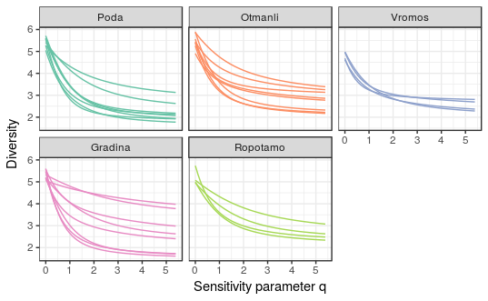

Now, it’s more clearly apparent: Gradina, Otmanli & Ropotamo have the most diverse communities. However, there is high variability between samples from the same station - very obvious e.g. for Gradina.  
Let’s calculate the average diversity profiles by station, because these last plots are very busy, it’s hard to distinguish anything.

`r`r (aver.weighted.div.profiles.zostera <- weighted.div.profiles.zostera.long %>% group_by(station, q) %>% summarise(value = mean(value)) )

| station | q | value |
| --- | --- | --- |
| Poda | 0.00 | 5.433495 |
| Poda | 0.11 | 5.119184 |
| Poda | 0.22 | 4.830275 |
| Poda | 0.33 | 4.567092 |
| Poda | 0.44 | 4.329246 |
| Poda | 0.55 | 4.115731 |
| Poda | 0.66 | 3.925061 |
| Poda | 0.77 | 3.755434 |
| Poda | 0.88 | 3.604881 |
| Poda | 0.99 | 3.471403 |

[output cut: 240 more lines]

`r`r ggplot(aver.weighted.div.profiles.zostera, aes(x = q, y = value, colour = station)) + geom_line(lwd = 0.75) + scale_color_brewer(palette = 2, labels = paste0(, as.numeric(unique(aver.weighted.div.profiles.zostera$station))))+ labs(x = parameter q, y = )

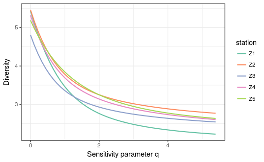

`r`r NA

Same conclusion as above. Also, Z1-Poda drops sharply - suggests presence of rare species & lower diversity.

###### **ABC curves**

First, we’ll calculate them on each replicate separately:

```r
(abc.zostera <- abc(zoo.abnd.zostera.long, zoo.biomass.zostera.long,
                 abnd.val = sp_count, biomass.val = sp_biomass,
                 station, year, month, replicate)
)
```

| station | year | month | replicate | sp_rank | cum_abnd | cum_biomass |
| --- | --- | --- | --- | --- | --- | --- |
| Poda | 2013 | 6 | a | 1 | 38.67277 | 26.82605 |
| Poda | 2013 | 6 | a | 2 | 58.12357 | 52.06806 |
| Poda | 2013 | 6 | a | 3 | 70.70938 | 76.85538 |
| Poda | 2013 | 6 | a | 4 | 76.20137 | 82.61954 |
| Poda | 2013 | 6 | a | 5 | 79.63387 | 86.74098 |
| Poda | 2013 | 6 | a | 6 | 82.60870 | 90.67175 |
| Poda | 2013 | 6 | a | 7 | 85.58352 | 93.79583 |
| Poda | 2013 | 6 | a | 8 | 87.87185 | 95.18921 |
| Poda | 2013 | 6 | a | 9 | 89.93135 | 96.33324 |
| Poda | 2013 | 6 | a | 10 | 91.30435 | 96.89058 |

[output cut: 990 more lines]

| station | year | month | replicate | w |
| --- | --- | --- | --- | --- |
| Poda | 2013 | 6 | a | 0.05069429 |
| Poda | 2013 | 6 | b | 0.18473303 |
| Poda | 2013 | 6 | c | 0.20337452 |
| Poda | 2013 | 6 | d | 0.13967494 |
| Poda | 2014 | 7 | a | 0.22149456 |
| Poda | 2014 | 7 | b | 0.11807257 |
| Poda | 2014 | 7 | c | 0.13023782 |
| Poda | 2014 | 7 | d | 0.22517665 |
| Otmanli | 2013 | 6 | a | 0.26910997 |
| Otmanli | 2013 | 6 | b | 0.11856229 |

[output cut: 22 more lines]

```r
## result is a list: 1) grouped df containing the curves (long), 2) summarized df with the W statistic per replicate - the distance between the 2 curves
```

We’ll plot W, because there are too many stations & replicates and the curves will be unreadable.

`r`r plot.w.zostera <- ggplot(abc.zostera[[2]], aes(x = station, y = w, colour = factor(year))) + geom_boxplot() + scale_color_viridis(option = , begin = 0.5, discrete = TRUE, name = \) + scale_x_discrete(name = , labels = paste0(, as.numeric(unique(abc.zostera[[2]]$station)))) + ylab() + geom_hline(yintercept = 0) ## modify text size a little (plot.w.zostera <- plot.w.zostera + text_size(text.x = rel(1.2), text.y = rel(1.2), legend.text = rel(1), title.x = rel(1.1), title.y = rel(1.1)) ) ## and save this.. ggsave(here::here(figures.dir, _zostera.png), plot.w.zostera, width = 15, units = , dpi = 300)

```
Saving 15 x 7.04 cm image
```

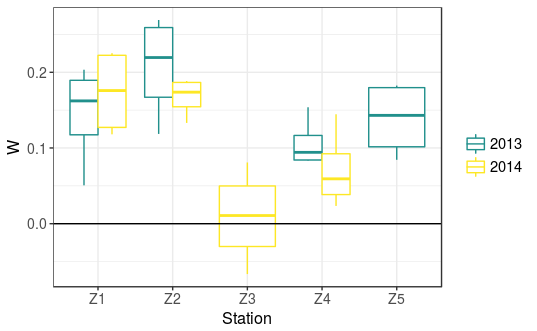

`r`r NA

W > 0 for most samples except Vromos => the biomass curve is above the abundance curve, so none of the stations/replicates can be considered terribly disturbed. The W values are closer to 0 than for the sand communities = the ABC curves in the seagrasses are even closer together. The mean W for Z3-Vromos is still above 0, but some of the samples are below => the curves are close together, suggesting disturbance. Not really very surprising, because 1) Vromos was close to an untreated sewage water source, and 2) there are less samples than for the other stations. Again, there is no evidence for complete dominance of one species in the biomass, perfectly even distribution of the abundance among species (W = 1, or tending towards it), nor the opposite (W = -1). In short, the structure of the communities is more or less even and normal, with variations characteristic of macrozoobenthic samples/communities. For Z2 & Z4, W decreases somewhat between 2013-2014. There might be some disturbance -> perhaps due to the heavy rains in the summer of 2014 - something to keep in mind just in case (again, prob. not enough time for the communities to display a reaction).

Plot the summary ABC curves - per station and year. 2 rows (for the 2 years) + 5 columns (stations) in the plot - will put it in landscape format in the text.  
The summary curves will be calculated on **data averaged by year** - again, to reduce the over-dominance of large mollusks etc. in the biomass.

```r
## summarize the abundance and biomass data per year (average)
(summary.abnd.zostera <- zoo.abnd.zostera.long %>%
   group_by(station, year, species) %>%
   summarize(mean_count = mean(sp_count))
)
```

| station | year | species | mean_count |
| --- | --- | --- | --- |
| Poda | 2013 | Abra alba | 7.50 |
| Poda | 2013 | Abra sp. | 0.00 |
| Poda | 2013 | Actiniaria | 0.25 |
| Poda | 2013 | Alitta succinea | 11.25 |
| Poda | 2013 | Ampelisca diadema | 14.00 |
| Poda | 2013 | Amphibalanus improvisus | 6.25 |
| Poda | 2013 | Ampithoe sp. | 0.00 |
| Poda | 2013 | Anadara kagoshimensis | 0.00 |
| Poda | 2013 | Apherusa bispinosa | 0.00 |
| Poda | 2013 | Apseudopsis ostroumovi | 0.00 |

[output cut: 742 more lines]

```r
(summary.biomass.zostera <- zoo.biomass.zostera.long %>%
   group_by(station, year, species) %>%
   summarize(mean_biomass = mean(sp_biomass))
)
```

| station | year | species | mean_biomass |
| --- | --- | --- | --- |
| Poda | 2013 | Abra alba | 0.137175 |
| Poda | 2013 | Abra sp. | 0.000000 |
| Poda | 2013 | Actiniaria | 0.000900 |
| Poda | 2013 | Alitta succinea | 0.004250 |
| Poda | 2013 | Ampelisca diadema | 0.010550 |
| Poda | 2013 | Amphibalanus improvisus | 0.021625 |
| Poda | 2013 | Ampithoe sp. | 0.000000 |
| Poda | 2013 | Anadara kagoshimensis | 0.000000 |
| Poda | 2013 | Apherusa bispinosa | 0.000000 |
| Poda | 2013 | Apseudopsis ostroumovi | 0.000000 |

[output cut: 742 more lines]

Now calculate the summary ABC for 2013 and 2014 for the zostera stations.

```r
(abc.summary.zostera <- abc(summary.abnd.zostera, summary.biomass.zostera,
                         abnd.val = mean_count, biomass.val = mean_biomass,
                         station, year)
)
```

| station | year | sp_rank | cum_abnd | cum_biomass |
| --- | --- | --- | --- | --- |
| Poda | 2013 | 1 | 37.93382 | 42.61350 |
| Poda | 2013 | 2 | 61.17837 | 55.68339 |
| Poda | 2013 | 3 | 67.23164 | 68.02916 |
| Poda | 2013 | 4 | 71.75141 | 75.19651 |
| Poda | 2013 | 5 | 75.38337 | 82.19475 |
| Poda | 2013 | 6 | 78.36965 | 86.29413 |
| Poda | 2013 | 7 | 80.87167 | 89.67891 |
| Poda | 2013 | 8 | 83.29298 | 91.73932 |
| Poda | 2013 | 9 | 85.63358 | 93.56391 |
| Poda | 2013 | 10 | 87.65133 | 95.03120 |

[output cut: 742 more lines]

| station | year | w |
| --- | --- | --- |
| Poda | 2013 | 0.05510287 |
| Poda | 2014 | 0.08700160 |
| Otmanli | 2013 | 0.14575778 |
| Otmanli | 2014 | 0.10103568 |
| Vromos | 2014 | -0.04911179 |
| Gradina | 2013 | 0.06275103 |
| Gradina | 2014 | 0.01891233 |
| Ropotamo | 2013 | 0.07990142 |

```
NA
```

All good, let’s plot them!

`r`r ## reshape the data for easier plotting - and to have a legend.. abc.summary.zostera.long <- abc.summary.zostera[[1]] %>% gather(key = variable, value = value, -c(station:sp_rank)) %>% mutate(variable = case_when(variable == _abnd ~ , variable == _biomass ~ )) ## make named character vector for the custom station labels  
stations.zostera <- paste0(, as.numeric(unique(abc.summary.zostera[[1]]$station))) names(stations.zostera) <- as.character(unique(abc.summary.zostera[[1]]$station)) ## plot plot.summary.abc.zostera <- ggplot(abc.summary.zostera.long, aes(x = sp_rank, y = value, colour = variable)) + geom_line() + # apply axis transformations scale_x_log10() + coord_trans(y = _logistic) + # curve colours and legend scale_colour_manual(values = c(, ), name = \) + theme(legend.position = ) + # facets & labels facet_grid(year ~ station, labeller = labeller(station = as_labeller(stations.zostera))) + labs(x = rank (log), y = %) ## modify text size a little (plot.summary.abc.zostera <- plot.summary.abc.zostera + text_size(text.x = rel(1.2), text.y = rel(1.2), legend.text = rel(1), title.x = rel(1.1), title.y = rel(1.1), strip.x = rel(1.1), strip.y = rel(1.1)) ) ## and save this - huge, because I think it will be displayed best as a whole-page graph.. ggsave(here::here(figures.dir, _abc_zostera.png), plot.summary.abc.zostera, width = 25, height = 15, units = , dpi = 300)

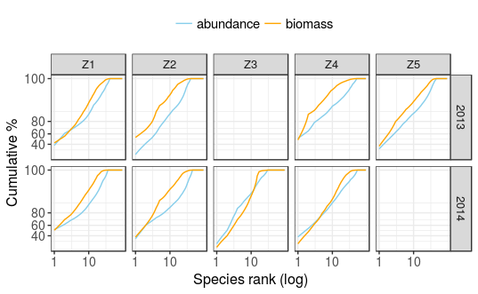

`r`r rm(abc.summary.zostera.long)

Overall, the biomass curve is above the abundance curve almost everywhere, with some exceptions: Z3-Vromos - as suggested by W; Z4-Gradina in 2014. The curves otherwise are very close together - indicative of a slight disturbance. Very characteristic of seagrass communities - appear disturbed because of the high natural organic loading (-> tolerant r-strategist species present even in the most pristine conditions). Must be taken into account when applying biotic indices - they will most likely function incorrectly!  
Z4 in 2014 - worse condition - similar to Z3 -> could be because of heavy rains on 2014-07-15/16 (samples from Z4 taken later than those at the other stations, on 2014-07-18 - after the rains). Not sure if relevant, though - how fast can the communities react? Was it enough of a disturbance?  
Results do not follow the pressure gradient at all - the curves at all stations are close to one another.  
Of course, another contributing factor could be insufficient replication which might hide dominance patterns…

Make a combined plot of W and ABC in the seagrasses.

`r`r (plot.abc.w.combined.zostera <- cowplot::plot_grid(plot.summary.abc.zostera, plot.w.zostera + theme(legend.position = ), labels = c(, ), ncol = 2, rel_widths = c(2,1)) ) ## save & clean up cowplot::save_plot(here::here(figures.dir, _w_combined_zostera.png), plot.abc.w.combined.zostera, base_width = 10, base_height = 6, dpi = 300)

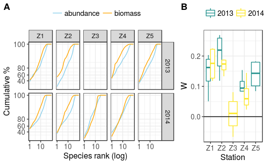

###### **Partial dominance curves**

`r`r ## will be calculated directly on the summarized abundance/biomass data (pd.summary.zostera <- partial_dominance_curves(summary.abnd.zostera, summary.biomass.zostera, abnd.val = mean_count, biomass.val = mean_biomass, station, year) )

| station | year | sp_rank | partial_abnd | partial_biomass |
| --- | --- | --- | --- | --- |
| Poda | 2013 | 1 | 37.933818 | 42.613501 |
| Poda | 2013 | 2 | 37.451235 | 22.775195 |
| Poda | 2013 | 3 | 15.592516 | 27.858103 |
| Poda | 2013 | 4 | 13.793103 | 22.418418 |
| Poda | 2013 | 5 | 12.857143 | 28.214732 |
| Poda | 2013 | 6 | 12.131148 | 23.023411 |
| Poda | 2013 | 7 | 11.567164 | 24.695864 |
| Poda | 2013 | 8 | 12.658228 | 19.963074 |
| Poda | 2013 | 9 | 14.009662 | 22.087659 |
| Poda | 2013 | 10 | 14.044944 | 22.797927 |

[output cut: 332 more lines]

`r`r ## reshape the data as before.. pd.summary.zostera.long <- pd.summary.zostera %>% gather(key = variable, value = value, -c(station:sp_rank)) %>% mutate(variable = case_when(variable == _abnd ~ , variable == _biomass ~ )) ## plot plot.pd.zostera <- ggplot(pd.summary.zostera.long, aes(x = sp_rank, y = value, colour = variable)) + geom_line() + # apply axis transformations scale_x_log10() + # curve colours and legend scale_colour_manual(values = c(, ), name = \) + theme(legend.position = ) + # facets & labels facet_grid(year ~ station, labeller = labeller(station = as_labeller(stations.zostera))) + labs(x = rank (log), y = %) ## modify text size a little (plot.pd.zostera <- plot.pd.zostera + text_size(text.x = rel(1.2), text.y = rel(1.2), title.x = rel(1.1), title.y = rel(1.1), strip.x = rel(1.1), strip.y = rel(1.1)) ) ## save, just in case, although I don’t much see the point in using ALL of them, when they’re showing basically the same thing.. ggsave(here::here(figures.dir, _pd_zostera.png), plot.pd.zostera, width = 25, height = 15, units = , dpi = 300)

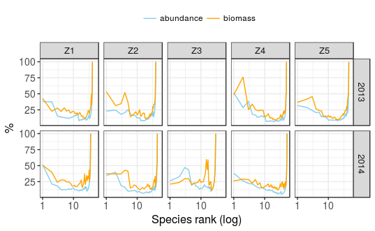

`r`r rm(pd.summary.zostera.long)

More or less the same pattern.. Interesting - compared to the partial dominance curves in the sand samples - much less dominance (both curves start at about the same level). There is also more variability - probably because the samples are smaller (taken with a corer) and fewer.

#### Macrozoobenthic communities in seagrass and sand in Sozopol Bay (2012)

Import the abundance & biomass data - again, from the cleaned & saved datasets, to avoid (most of) the cleaning steps.

`r`r ## dimensions should be 48 x 206 (6 metadata + 200 species columns); all species columns should be numeric. zoo.abnd.2012 <- read_csv(here::here(save.dir, _2012_orig_clean.csv)) ## same for biomass; same expected structure as the abundance zoo.biomass.2012 <- read_csv(here::here(save.dir, _2012_orig_clean.csv))

Convert columns to the proper type, arrange the datasets by habitat & station, etc.

`r`r zoo.abnd.2012 <- zoo.abnd.2012 %>% mutate(station = factor(station, levels = c(1, 2, 1, 2, 1, 2)), site = factor(site, levels = c(, , ))) %>% arrange(habitat, site, station) zoo.biomass.2012 <- zoo.biomass.2012 %>% mutate(station = factor(station, levels = c(1, 2, 1, 2, 1, 2)), site = factor(site, levels = c(, , ))) %>% arrange(habitat, site, station)

Remove all species not present in the datasets (= all-0 columns).

`r`r ## result should have dimensions 48 x 64 (58 species + 6 metadata columns) zoo.abnd.2012 <- zoo.abnd.2012 %>% gather(key = species, value = sp_count, -c(site:replicate)) %>% group_by(species) %>% filter(sp_count > 0) %>% spread(species, sp_count, fill = 0) %>% arrange(habitat, site, station) zoo.biomass.2012 <- zoo.biomass.2012 %>% gather(key = species, value = sp_biomass, -c(site:replicate)) %>% group_by(species) %>% filter(sp_biomass > 0) %>% spread(species, sp_biomass, fill = 0) %>% arrange(habitat, site, station)

Transform to long format.

`r`r zoo.abnd.2012.long <- zoo.abnd.2012 %>% gather(key = species, value = sp_count, -c(site:replicate)) zoo.biomass.2012.long <- zoo.biomass.2012 %>% gather(key = species, value = sp_biomass, -c(site:replicate))

##### Alpha diversity indices

`r`r ## uses custom function for convenience - has to be imported first! alpha.div.2012 <- zoo.abnd.2012 %>% select(-c(site:replicate)) %>% alpha_diversity() ## add the metadata columns (row order is not changed, so possible) (alpha.div.2012 <- bind_cols(zoo.abnd.2012 %>% select(site:replicate), alpha.div.2012) )

| site | station | month | year | habitat | replicate | sp_richness | shannon_h | evenness_j | h_effective |
| --- | --- | --- | --- | --- | --- | --- | --- | --- | --- |
| Konski | Konski1 | 7 | 2012 | S | a | 14 | 2.1508272 | 0.8149983 | 8.591963 |
| Konski | Konski1 | 7 | 2012 | S | b | 14 | 2.1016101 | 0.7963488 | 8.179329 |
| Konski | Konski1 | 7 | 2012 | S | c | 16 | 2.2603617 | 0.8152532 | 9.586556 |
| Konski | Konski1 | 7 | 2012 | S | d | 12 | 1.5824447 | 0.6368226 | 4.866839 |
| Konski | Konski2 | 7 | 2012 | S | a | 19 | 1.9765566 | 0.6712846 | 7.217846 |
| Konski | Konski2 | 7 | 2012 | S | b | 4 | 1.0102099 | 0.7287124 | 2.746178 |
| Konski | Konski2 | 7 | 2012 | S | c | 14 | 2.0935971 | 0.7933125 | 8.114050 |
| Konski | Konski2 | 7 | 2012 | S | d | 18 | 1.7353913 | 0.6004042 | 5.671146 |
| Ribka | Ribka1 | 7 | 2012 | S | a | 6 | 1.2326714 | 0.6879670 | 3.430381 |
| Ribka | Ribka1 | 7 | 2012 | S | b | 3 | 0.9908354 | 0.9018972 | 2.693484 |

[output cut: 38 more lines]

Summarize these diversity indices by site & habitat.

`r`r ## STILL haven’t learned how to use the functions from package sjPlot for printing pretty (and easy!) tables…  
alpha.div.2012 %>% group_by(site, habitat) %>% summarise(h_mean = mean(shannon_h), h_sd = sd(shannon_h), j_mean = mean(evenness_j, na.rm = TRUE), j_sd = sd(evenness_j, na.rm = TRUE), h_eff_mean = mean(h_effective), h_eff_sd = sd(h_effective), nb_replicates = n() ) %>% arrange(habitat, site)

| site | habitat | h_mean | h_sd | j_mean | j_sd | h_eff_mean | h_eff_sd | nb_replicates |
| --- | --- | --- | --- | --- | --- | --- | --- | --- |
| Konski | S | 1.8638748 | 0.4116146 | 0.7321421 | 0.08601744 | 6.871738 | 2.273563 | 8 |
| Ribka | S | 0.9204483 | 0.4971216 | 0.7609226 | 0.19659398 | 2.817141 | 1.560035 | 8 |
| Gradina | S | 1.0338475 | 0.5354104 | 0.8774383 | 0.10953203 | 3.133753 | 1.391499 | 8 |
| Konski | Z | 1.3435439 | 0.6914672 | 0.5082000 | 0.21621673 | 4.629592 | 2.796974 | 8 |
| Ribka | Z | 1.5521138 | 0.2765660 | 0.7761287 | 0.10729563 | 4.890304 | 1.459044 | 8 |
| Gradina | Z | 1.2392246 | 0.5258999 | 0.5761558 | 0.16249802 | 3.955544 | 2.503065 | 8 |

2. Species accumulation curves

`r`r sac.2012 <- specaccum(select(zoo.abnd.2012, -c(site:replicate))) plot(sac.2012, xlab = , ylab = species richness, ci.type = , ci.col = blue)

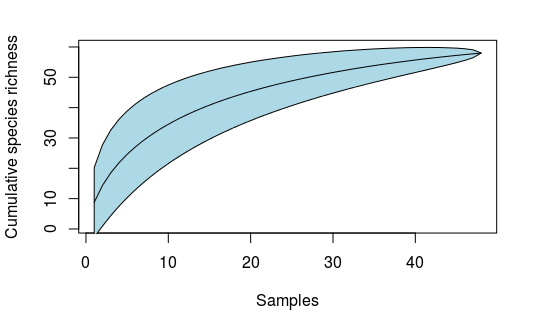

Again, about 10 (maybe a little more) samples seem to be enough to capture most of the biodiversity in the study area (in terms of species richness) - this is where the curve starts to smooth out (slope < 1). In reality, there are 4 samples/station & habitat, or 8 samples/site & habitat - clearly not enough. Also supported by the horrifying species richness values (sometimes only 1 species??). I’m putting it down as a result of my learning the taxonomy, methods etc.  
I’m going to go through the motions of analyzing this dataset in the same way as the previous 2, but I’m not going to trust the results very much.

##### Species pool

Estimate the number of **unobserved species** in the study area.  
First - in the different habitats in Sozopol Bay.

`r`r ## this function is based on incidences in sample sites - presence/absence data; gives a single estimate for a collection of sample sites specpool(select(zoo.abnd.2012, -c(site:replicate)), pool = zoo.abnd.2012$habitat, smallsample = TRUE) r ## this function is quantitative - based on abundances on single sample site estimateR(select(zoo.abnd.2012, -c(site:replicate)))

```
              [,1]      [,2]      [,3]      [,4]      [,5]      [,6]
S.obs    14.000000 14.000000 16.000000 12.000000 19.000000 4.0000000
S.chao1  17.000000 16.000000 19.333333 15.000000 19.750000 4.0000000
se.chao1  4.139125  2.867442  4.105716  4.133199  1.418211 0.2165064
S.ACE    17.198261 17.246512 20.422899 14.360111 20.546099 4.6944444
se.ACE    1.849899  1.901694  2.110162  1.717498  2.041041 0.9965817
              [,7]      [,8]     [,9]        [,10]   [,11] [,12]
S.obs    14.000000 18.000000 6.000000 3.000000e+00 3.00000     2
S.chao1  21.500000 21.333333 6.333333 3.000000e+00 4.00000     2
se.chao1  8.102810  4.107949 0.909305 0.000000e+00 2.12132     0
S.ACE    21.470588 21.529548 7.428571 3.000000e+00     NaN     2
se.ACE    2.058296  2.145758 1.334865 1.825012e-08     NaN     0
             [,13]     [,14]     [,15] [,16]        [,17] [,18] [,19]
S.obs     8.000000 2.0000000 2.0000000     4 3.000000e+00     2     1
S.chao1  11.000000 2.0000000 2.0000000     4 3.000000e+00     2     1
se.chao1  4.114829 0.3535534 0.3535534     0 0.000000e+00     0     0
S.ACE    13.473580 3.1250000 3.1020408     4 3.000000e+00     2     1
se.ACE    1.952554 0.7548415 0.8243615     0 1.825012e-08     0     0
             [,20]    [,21]    [,22]        [,23]    [,24]    [,25]
S.obs    5.0000000  4.00000 6.000000 3.000000e+00 6.000000 5.000000
S.chao1  5.0000000 10.00000 7.000000 3.000000e+00 7.500000 8.000000
se.chao1 0.0000000  6.97137 1.790628 0.000000e+00 2.539685 4.383919
S.ACE    5.0000000      NaN 8.571429 3.000000e+00 9.685714      NaN
se.ACE   0.8944272      NaN 1.439238 1.490116e-08 1.388071      NaN
            [,26]     [,27]     [,28]     [,29]     [,30]     [,31]
S.obs    7.000000 16.000000 17.000000 24.000000 14.000000 14.000000
S.chao1  7.500000 19.333333 19.000000 25.111111 20.000000 16.000000
se.chao1 1.269843  4.105716  2.578249  1.573732  7.197222  2.867442
S.ACE    8.801615 21.302005 20.891026 28.863008 16.776296 18.310744
se.ACE   1.378174  2.273866  2.169643  2.759292  1.909703  2.229964
             [,32]     [,33]    [,34]     [,35]      [,36]     [,37]
S.obs    12.000000 10.000000 6.000000 5.0000000 10.0000000 4.0000000
S.chao1  13.500000 13.000000 7.000000 5.0000000 10.3333333 4.0000000
se.chao1  2.565801  4.125437 2.220039 0.2236068  0.9159196 0.4330127
S.ACE    15.966818 21.012346 7.932334 5.9635569 11.5389643 4.3935185
se.ACE    2.148252  2.230432 1.376601 1.1780672  1.6591068 0.6374892
             [,38]     [,39]     [,40]     [,41]     [,42]     [,43]
S.obs    10.000000  9.000000 10.000000  7.000000  8.000000  7.000000
S.chao1  11.500000 19.000000 11.500000 13.000000  8.750000  8.000000
se.chao1  2.560146 10.150188  2.560146  7.076505  1.411093  1.794088
S.ACE    12.517273 16.868722 12.227910 15.203070 10.333333 11.530000
se.ACE    1.642815  2.097805  1.350818  1.879915  1.580398  1.757765
             [,44]     [,45]    [,46]     [,47]     [,48]
S.obs    5.0000000 24.000000 6.000000 12.000000  7.000000
S.chao1  5.0000000 35.250000 7.000000 14.000000 10.000000
se.chao1 0.4472136  9.535120 2.220039  2.864673  4.441284
S.ACE    5.4176955 41.131051 7.372086 15.778821 10.979592
se.ACE   0.9782301  3.641516 1.283443  1.887387  1.438721
```

|  | Species | chao | chao.se | jack1 | jack1.se | jack2 | boot | boot.se | n |
| --- | --- | --- | --- | --- | --- | --- | --- | --- | --- |
| S | 42 | 55.49653 | 9.995198 | 54.45833 | 4.205857 | 61.11413 | 47.82345 | 3.119324 | 24 |
| Z | 47 | 58.56845 | 8.477327 | 59.45833 | 6.953841 | 65.23732 | 52.90229 | 4.025564 | 24 |

In the sandy sediments in Sozopol Bay, 69 % of the species pool are captured based on the most severe measure (second-order jacknife), and 87.5 % - based on the most forgiving measure (bootstrap).  
In the seagrasses in Sozopol Bay, 72 % of the species pool are captured based on the most severe measure (second-order jacknife), and 90 % - based on the most forgiving measure (bootstrap).

In reality, the two habitats were not really distinct - the sand samples were taken too close to the seagrass meadows, in the case of Gradina - in unvegetated patches INSIDE the meadows, so I’m not sure if a distinction is possible/meaningful from this data.

Then - at the different sites.

`r`r ## this function is based on incidences in sample sites - presence/absence data; gives a single estimate for a collection of sample sites specpool(select(zoo.abnd.2012, -c(site:replicate)), pool = zoo.abnd.2012$site, smallsample = TRUE) r ## this function is quantitative - based on abundances on single sample site estimateR(select(zoo.abnd.2012, -c(site:replicate)))

```
              [,1]      [,2]      [,3]      [,4]      [,5]      [,6]
S.obs    14.000000 14.000000 16.000000 12.000000 19.000000 4.0000000
S.chao1  17.000000 16.000000 19.333333 15.000000 19.750000 4.0000000
se.chao1  4.139125  2.867442  4.105716  4.133199  1.418211 0.2165064
S.ACE    17.198261 17.246512 20.422899 14.360111 20.546099 4.6944444
se.ACE    1.849899  1.901694  2.110162  1.717498  2.041041 0.9965817
              [,7]      [,8]     [,9]        [,10]   [,11] [,12]
S.obs    14.000000 18.000000 6.000000 3.000000e+00 3.00000     2
S.chao1  21.500000 21.333333 6.333333 3.000000e+00 4.00000     2
se.chao1  8.102810  4.107949 0.909305 0.000000e+00 2.12132     0
S.ACE    21.470588 21.529548 7.428571 3.000000e+00     NaN     2
se.ACE    2.058296  2.145758 1.334865 1.825012e-08     NaN     0
             [,13]     [,14]     [,15] [,16]        [,17] [,18] [,19]
S.obs     8.000000 2.0000000 2.0000000     4 3.000000e+00     2     1
S.chao1  11.000000 2.0000000 2.0000000     4 3.000000e+00     2     1
se.chao1  4.114829 0.3535534 0.3535534     0 0.000000e+00     0     0
S.ACE    13.473580 3.1250000 3.1020408     4 3.000000e+00     2     1
se.ACE    1.952554 0.7548415 0.8243615     0 1.825012e-08     0     0
             [,20]    [,21]    [,22]        [,23]    [,24]    [,25]
S.obs    5.0000000  4.00000 6.000000 3.000000e+00 6.000000 5.000000
S.chao1  5.0000000 10.00000 7.000000 3.000000e+00 7.500000 8.000000
se.chao1 0.0000000  6.97137 1.790628 0.000000e+00 2.539685 4.383919
S.ACE    5.0000000      NaN 8.571429 3.000000e+00 9.685714      NaN
se.ACE   0.8944272      NaN 1.439238 1.490116e-08 1.388071      NaN
            [,26]     [,27]     [,28]     [,29]     [,30]     [,31]
S.obs    7.000000 16.000000 17.000000 24.000000 14.000000 14.000000
S.chao1  7.500000 19.333333 19.000000 25.111111 20.000000 16.000000
se.chao1 1.269843  4.105716  2.578249  1.573732  7.197222  2.867442
S.ACE    8.801615 21.302005 20.891026 28.863008 16.776296 18.310744
se.ACE   1.378174  2.273866  2.169643  2.759292  1.909703  2.229964
             [,32]     [,33]    [,34]     [,35]      [,36]     [,37]
S.obs    12.000000 10.000000 6.000000 5.0000000 10.0000000 4.0000000
S.chao1  13.500000 13.000000 7.000000 5.0000000 10.3333333 4.0000000
se.chao1  2.565801  4.125437 2.220039 0.2236068  0.9159196 0.4330127
S.ACE    15.966818 21.012346 7.932334 5.9635569 11.5389643 4.3935185
se.ACE    2.148252  2.230432 1.376601 1.1780672  1.6591068 0.6374892
             [,38]     [,39]     [,40]     [,41]     [,42]     [,43]
S.obs    10.000000  9.000000 10.000000  7.000000  8.000000  7.000000
S.chao1  11.500000 19.000000 11.500000 13.000000  8.750000  8.000000
se.chao1  2.560146 10.150188  2.560146  7.076505  1.411093  1.794088
S.ACE    12.517273 16.868722 12.227910 15.203070 10.333333 11.530000
se.ACE    1.642815  2.097805  1.350818  1.879915  1.580398  1.757765
             [,44]     [,45]    [,46]     [,47]     [,48]
S.obs    5.0000000 24.000000 6.000000 12.000000  7.000000
S.chao1  5.0000000 35.250000 7.000000 14.000000 10.000000
se.chao1 0.4472136  9.535120 2.220039  2.864673  4.441284
S.ACE    5.4176955 41.131051 7.372086 15.778821 10.979592
se.ACE   0.9782301  3.641516 1.283443  1.887387  1.438721
```

|  | Species | chao | chao.se | jack1 | jack1.se | jack2 | boot | boot.se | n |
| --- | --- | --- | --- | --- | --- | --- | --- | --- | --- |
| Konski | 46 | 59.50000 | 10.521407 | 57.2500 | 4.021427 | 63.66667 | 51.13096 | 2.371546 | 16 |
| Ribka | 26 | 32.69643 | 5.571294 | 35.3750 | 4.681246 | 38.40833 | 30.43644 | 2.558351 | 16 |
| Gradina | 31 | 57.36719 | 19.635901 | 45.0625 | 9.971639 | 54.92083 | 36.93530 | 5.498352 | 16 |

Let’s do one final estimate of the whole Sozopol Bay - all samples pooled.

`r`r ## this function is based on incidences in sample sites - presence/absence data; gives a single estimate for a collection of sample sites specpool(select(zoo.abnd.2012, -c(site:replicate)), smallsample = TRUE)

|  | Species | chao | chao.se | jack1 | jack1.se | jack2 | boot | boot.se | n |
| --- | --- | --- | --- | --- | --- | --- | --- | --- | --- |
| All | 58 | 64.40909 | 4.882158 | 69.75 | 4.822365 | 70.93262 | 64.1866 | 3.148988 | 48 |

##### Taxonomic distance & diversity

Calculate the **taxonomic distance** for the zoobenthic communities in Sozopol Bay in 2012. Again, this cannot be considered relevant / meaningful, since there are samples containing a single species which ought to be excluded altogether from all further analysis…

`r`r ## we’ll use the same taxonomic distance for the master species list as before ## calculate the taxonomic distinctness indices for the abundance dataset (tax.distinctness.2012 <- taxondive(select(zoo.abnd.2012, -c(site:replicate)), tax.dist.all) )

```
Dimensions do not match between 'comm' and 'dis'
Matched 'dis' labels by 'comm' names
         Species   Delta  Delta* Lambda+  Delta+ S Delta+
          14.000  73.529  85.400 358.883  87.204  1220.86
          14.000  73.083  87.084 363.549  87.822  1229.51
          16.000  75.371  87.367 341.370  87.312  1396.99
          12.000  65.240  92.694 435.017  86.109  1033.31
          19.000  69.353  88.621 463.808  80.245  1524.66
           4.000  45.776  79.875 325.260  87.259   349.04
          14.000  74.140  87.170 423.740  81.887  1146.42
          18.000  54.618  75.086 364.151  85.414  1537.45
           6.000  50.940  84.695 436.695  89.220   535.32
           3.000  62.063  95.833 123.904  92.129   276.39
           3.000  21.146  82.236 302.500  87.702   263.10
           2.000  41.666  76.387   0.000  76.387   152.77
           8.000  68.198  81.551 261.312  83.650   669.20
           2.000  24.179  60.448   0.000  60.448   120.90
           2.000  25.000 100.000   0.000 100.000   200.00
           4.000  69.536  93.055 123.904  92.129   368.52
           3.000  45.606  74.110  56.454  71.074   213.22
           2.000  42.857 100.000   0.000 100.000   200.00
           1.000   0.000
           5.000  58.357  82.176 256.729  81.582   407.91
           4.000  85.537  85.537 237.402  85.537   342.15
           6.000  80.651  90.732 211.991  91.578   549.47
           3.000  49.519  70.410  56.454  71.074   213.22
           6.000  44.482  72.979 240.492  80.008   480.05
           5.000  11.611  67.704 192.643  91.322   456.61
           7.000  11.357  68.932  56.166  69.936   489.55
          16.000  33.590  86.780 314.007  87.886  1406.18
          17.000  41.649  84.363 366.726  87.725  1491.33
          24.000  66.193  80.658 345.392  87.363  2096.71
          14.000  67.408  85.631 357.084  85.758  1200.61
          14.000  66.226  85.224 368.767  85.163  1192.29
          12.000  61.202  87.515 246.389  90.392  1084.70
          10.000  50.198  81.275 238.224  85.230   852.30
           6.000  63.876  84.863 213.918  88.607   531.64
           5.000  55.582  80.808 201.843  88.961   444.80
          10.000  54.348  81.279 345.111  87.640   876.40
           4.000  59.369  78.488 216.167  85.980   343.92
          10.000  73.146  90.669 337.816  87.810   878.10
           9.000  65.691  86.600 287.912  87.909   791.18
          10.000  78.653  90.496 361.611  87.227   872.27
           7.000  27.953  74.760 431.171  75.592   529.15
           8.000  20.920  73.734 513.431  79.715   637.72
           7.000  25.357  73.478 253.616  84.216   589.51
           5.000  36.700  70.214 235.993  67.005   335.03
          24.000  72.626  86.909 444.985  83.287  1998.88
           6.000  57.002  79.084 516.293  76.888   461.33
          12.000  56.798  77.316 519.669  82.110   985.32
           7.000  38.876  62.400 293.564  65.770   460.39
Expected          69.940  68.964          85.476
```

`r`r ## get the summary - includes a significance test on Delta+ summary(tax.distinctness.2012)

```
            Delta   Delta*   Delta+ sd(Delta+) z(Delta+)  Pr(>|z|)
          73.5288  85.4005  87.2042     3.1705    0.5452 0.5856197
          73.0827  87.0835  87.8223     3.1705    0.7401 0.4592121
          75.3708  87.3669  87.3121     2.8386    0.6470 0.5176477
          65.2405  92.6944  86.1091     3.5964    0.1761 0.8601764
          69.3532  88.6210  80.2451     2.4524   -2.1328 0.0329427 *
          45.7762  79.8748  87.2589     9.3093    0.1916 0.8480874
          74.1401  87.1697  81.8872     3.1705   -1.1318 0.2577239
          54.6184  75.0858  85.4140     2.5695   -0.0240 0.9808777
          50.9396  84.6948  89.2196     6.4124    0.5839 0.5593062
          62.0633  95.8330  92.1290    12.4929    0.5326 0.5943272
          21.1463  82.2357  87.7016    12.4929    0.1782 0.8585798
          41.6657  76.3871  76.3871    20.3527   -0.4465 0.6552005
          68.1980  81.5514  83.6502     5.0167   -0.3639 0.7159554
          24.1794  60.4484  60.4484    20.3527   -1.2297 0.2188193
          25.0000 100.0000 100.0000    20.3527    0.7136 0.4754530
          69.5356  93.0550  92.1290     9.3093    0.7147 0.4747882
          45.6062  74.1102  71.0742    12.4929   -1.1528 0.2490080
          42.8571 100.0000 100.0000    20.3527    0.7136 0.4754530
           0.0000                          Inf
          58.3568  82.1759  81.5819     7.5465   -0.5160 0.6058870
          85.5371  85.5371  85.5371     9.3093    0.0066 0.9947284
          80.6506  90.7319  91.5781     6.4124    0.9517 0.3412691
          49.5192  70.4101  71.0742    12.4929   -1.1528 0.2490080
          44.4824  72.9789  80.0078     6.4124   -0.8527 0.3938295
          11.6105  67.7045  91.3223     7.5465    0.7747 0.4384877
          11.3573  68.9324  69.9357     5.6140   -2.7681 0.0056389 **
          33.5898  86.7802  87.8864     2.8386    0.8493 0.3957227
          41.6494  84.3632  87.7253     2.6976    0.8340 0.4042950
          66.1926  80.6580  87.3630     1.9839    0.9513 0.3414389
          67.4080  85.6308  85.7580     3.1705    0.0891 0.9290183
          66.2256  85.2239  85.1633     3.1705   -0.0985 0.9215389
          61.2018  87.5146  90.3920     3.5964    1.3670 0.1716224
          50.1976  81.2750  85.2297     4.1730   -0.0589 0.9530076
          63.8756  84.8633  88.6068     6.4124    0.4883 0.6253389
          55.5820  80.8077  88.9610     7.5465    0.4619 0.6441876
          54.3484  81.2788  87.6399     4.1730    0.5186 0.6040100
          59.3693  78.4883  85.9798     9.3093    0.0542 0.9568028
          73.1461  90.6694  87.8104     4.1730    0.5595 0.5758142
          65.6914  86.6005  87.9087     4.5499    0.5348 0.5928153
          78.6530  90.4960  87.2267     4.1730    0.4196 0.6747635
          27.9535  74.7595  75.5924     5.6140   -1.7605 0.0783301 .
          20.9196  73.7342  79.7154     5.0167   -1.1482 0.2508852
          25.3569  73.4784  84.2159     5.6140   -0.2244 0.8224577
          36.7000  70.2143  67.0053     7.5465   -2.4475 0.0143841 *
          72.6257  86.9086  83.2865     1.9839   -1.1034 0.2698480
          57.0017  79.0842  76.8881     6.4124   -1.3392 0.1805084
          56.7983  77.3158  82.1097     3.5964   -0.9359 0.3493212
          38.8763  62.4001  65.7698     5.6140   -3.5101 0.0004479 ***
Expected  69.9397  68.9638  85.4756
---
Signif. codes:  0 ‘***’ 0.001 ‘**’ 0.01 ‘*’ 0.05 ‘.’ 0.1 ‘ ’ 1
```

Plot the observed values of D-plus in the two habitats, and add the confidence limits.

`r`r s.l.dplus.2012 <- bind_cols(S = tax.distinctness.2012$Species, Dplus = tax.distinctness.2012$Dplus, Lambda = tax.distinctness.2012$Lambda, site = zoo.abnd.2012$site, habitat = zoo.abnd.2012$habitat) plot.dplus.2012 <- ggplot(s.l.dplus.2012, aes(x = S, y = Dplus, color = site)) + scale_color_brewer(palette = 2, labels = c(, , ) + geom_point(alpha = 0.85, size = 2) + xlim(0, 100) + labs(x = of species, y = expression(paste(Delta, +))) + facet_wrap(~habitat, labeller = as_labeller(c( = , = ))) + text_size(text.x = rel(1.2), text.y = rel(1.2), legend.text = rel(1.1), strip.x = rel(1.1), title.x = rel(1.1), title.y = rel(1.1), legend.title = rel(1.1))

## add confidence/tolerance lines

(plot.dplus.2012 <- plot.dplus.2012 + geom_line(aes(x = sp_number, y = lower), data = dplus.sim.conf.int, color = 40, lwd = 0.3) + geom_line(aes(x = sp_number, y = upper), data = dplus.sim.conf.int, color = 40, lwd = 0.3) + geom_line(aes(x = sp_number, y = average), data = dplus.sim.conf.int, color = 40, lwd = 0.3) )

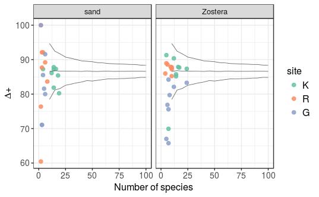

Again, there are too few species in the samples for this to be a meaningful analysis. Many of the samples would have a disturbed community structure if the results could be trusted - esp. G in seagrass, and also somewhat in sand. Overall, K samples which have the highest species richness in both sand and in seagrass are the closest to the average expected Delta+.

Now plot the observed Lambda values, with the theoretical (simulated) confidence intervals.

`r`r plot.lambda.2012 <- ggplot(s.l.dplus.2012, aes(x = S, y = Lambda, color = site)) + scale_color_brewer(palette = 2, labels = c(, , ) + geom_point(alpha = 0.85, size = 2) + xlim(0, 100) + labs(x = of species, y = expression(paste(Lambda, +))) + facet_wrap(~habitat, labeller = as_labeller(c( = , = ))) + text_size(text.x = rel(1.2), text.y = rel(1.2), legend.text = rel(1.1), strip.x = rel(1.1), title.x = rel(1.1), title.y = rel(1.1), legend.title = rel(1.1)) ## add the confidence/tolerance intervals (plot.lambda.2012 <- plot.lambda.2012 + geom_line(aes(x = sp_number, y = lower), data = lambda.sim.conf.int, color = 40, lwd = 0.3) + geom_line(aes(x = sp_number, y = upper), data = lambda.sim.conf.int, color = 40, lwd = 0.3) + geom_line(aes(x = sp_number, y = average), data = lambda.sim.conf.int, color = 40, lwd = 0.3) )

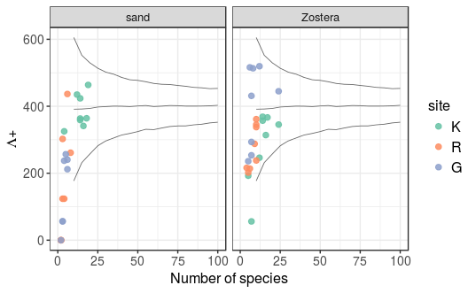

Same story here: very high variability between samples, mostly very low values of Lambda - because the few species that are present are of similar taxonomic groups. Site K is again the closest to the expected average values.

[output not shown]

`r`r ## get the legend from one of the plots, and put it at the bottom dplus.legend <- cowplot::get_legend(plot.dplus.2012 + theme(legend.position = ))

```
Removed 1 rows containing missing values (geom_point).Removed 10 rows containing missing values (geom_path).Removed 10 rows containing missing values (geom_path).Removed 10 rows containing missing values (geom_path).
```

`r`r (plot.dplus.l.combined.2012 <- cowplot::plot_grid(plot.dplus.l.combined.2012, dplus.legend, ncol = 2, rel_widths = c(1, 0.25)) ) ## save & clean up cowplot::save_plot(here::here(figures.dir, _lambda_combined_2012.png), plot.dplus.l.combined.2012, base_aspect_ratio = 0.9, base_width = 5.5, dpi = 300)

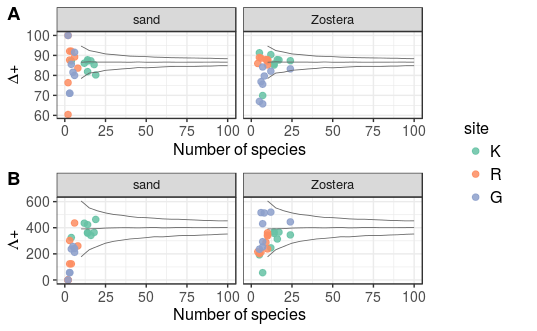

`r`r rm(dplus.legend)

Same conclusions as above. Probably won’t include these in the thesis results, and won’t pool them with the other seagrass samples (which were collected in the same way) - this only showcases the need for proper training before embarking on experiments. Any and all conclusions based on this data can only be tentative and partial, and more than a little doubtful.

##### Graphical analyses

###### **ABC curves**

First, we’ll calculate them on each replicate separately:

`r`r (abc.2012 <- abc(zoo.abnd.2012.long, zoo.biomass.2012.long, abnd.val = sp_count, biomass.val = sp_biomass, site, station, habitat, replicate) )

| site | station | habitat | replicate | sp_rank | cum_abnd | cum_biomass |
| --- | --- | --- | --- | --- | --- | --- |
| Konski | Konski1 | S | a | 1 | 24.36975 | 62.18875 |
| Konski | Konski1 | S | a | 2 | 42.85714 | 85.05665 |
| Konski | Konski1 | S | a | 3 | 56.30252 | 94.56883 |
| Konski | Konski1 | S | a | 4 | 69.74790 | 96.68397 |
| Konski | Konski1 | S | a | 5 | 79.83193 | 98.44121 |
| Konski | Konski1 | S | a | 6 | 84.03361 | 99.50302 |
| Konski | Konski1 | S | a | 7 | 88.23529 | 99.68112 |
| Konski | Konski1 | S | a | 8 | 91.59664 | 99.77441 |
| Konski | Konski1 | S | a | 9 | 94.95798 | 99.86261 |
| Konski | Konski1 | S | a | 10 | 96.63866 | 99.90841 |

[output cut: 990 more lines]

`r`r ## result is a list: 1) grouped df containing the curves (long), 2) summarized df with the W statistic per replicate - the distance between the 2 curves

| site | station | habitat | replicate | w |
| --- | --- | --- | --- | --- |
| Konski | Konski1 | S | a | 0.32619372 |
| Konski | Konski1 | S | b | 0.28815476 |
| Konski | Konski1 | S | c | 0.27626141 |
| Konski | Konski1 | S | d | 0.21602529 |
| Konski | Konski1 | Z | a | 0.03095100 |
| Konski | Konski1 | Z | b | 0.03518577 |
| Konski | Konski1 | Z | c | 0.08992744 |
| Konski | Konski1 | Z | d | 0.06716649 |
| Konski | Konski2 | S | a | 0.20191738 |
| Konski | Konski2 | S | b | 0.33759596 |

[output cut: 38 more lines]

We’ll plot W, because there are too many sites & replicates and the curves will be unreadable.

`r`r plot.w.2012 <- ggplot(abc.2012[[2]], aes(x = site, y = w, colour = factor(habitat))) + geom_boxplot() + scale_color_viridis(option = , begin = 0.25, discrete = TRUE, name = \, labels = c(, )) + scale_x_discrete(name = , labels = c(, , ) + ylab() + geom_hline(yintercept = 0) ## modify text size a little (plot.w.2012 <- plot.w.2012 + text_size(text.x = rel(1.2), text.y = rel(1.2), legend.text = rel(1), title.x = rel(1.1), title.y = rel(1.1)) ) ## and save this.. ggsave(here::here(figures.dir, _2012.png), plot.w.2012, width = 15, units = , dpi = 300)

```
Saving 15 x 8.76 cm image
```

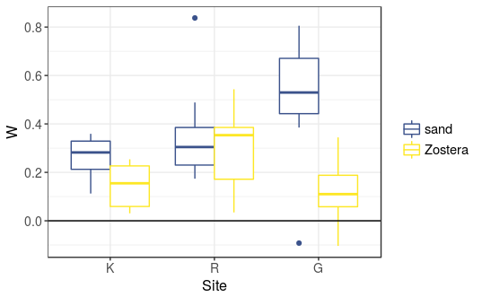

`r`r NA

W > 0 for most samples, but the variability is incredibly high, esp. at site G (+ an incredible difference between sand and seagrass there) - hardly surprising; those samples contain the lowest number of species. Just as biased as the previous analysis.

`r`r ## summarize the abundance and biomass data per year (average)  
(summary.abnd.2012 <- zoo.abnd.2012.long %>% group_by(site, habitat, species) %>% summarize(mean_count = mean(sp_count)) ) r (summary.biomass.2012 <- zoo.biomass.2012.long %>% group_by(site, habitat, species) %>% summarize(mean_biomass = mean(sp_biomass)) )

| site | habitat | species | mean_count |
| --- | --- | --- | --- |
| Konski | S | Abra prismatica | 0.500 |
| Konski | S | Abra segmentum | 1.000 |
| Konski | S | Ampelisca diadema | 1.000 |
| Konski | S | Ampharetidae | 0.250 |
| Konski | S | Amphibalanus improvisus | 0.000 |
| Konski | S | Amphipoda | 0.500 |
| Konski | S | Bittium reticulatum | 25.500 |
| Konski | S | Brachynotus sexdentatus | 0.000 |
| Konski | S | Capitella capitata | 3.875 |
| Konski | S | Capitellidae | 0.000 |

[output cut: 338 more lines]

| site | habitat | species | mean_biomass |
| --- | --- | --- | --- |
| Konski | S | Abra prismatica | 0.0028500 |
| Konski | S | Abra segmentum | 0.0757500 |
| Konski | S | Ampelisca diadema | 0.0010375 |
| Konski | S | Ampharetidae | 0.0008375 |
| Konski | S | Amphibalanus improvisus | 0.0000000 |
| Konski | S | Amphipoda | 0.0005125 |
| Konski | S | Bittium reticulatum | 0.2357000 |
| Konski | S | Brachynotus sexdentatus | 0.0000000 |
| Konski | S | Capitella capitata | 0.0013250 |
| Konski | S | Capitellidae | 0.0000000 |

[output cut: 338 more lines]

Now calculate the summary ABC for the seagrass and the sand communities for the 2012 stations.

`r`r (abc.summary.2012 <- abc(summary.abnd.2012, summary.biomass.2012, abnd.val = mean_count, biomass.val = mean_biomass, site, habitat) )

| site | habitat | sp_rank | cum_abnd | cum_biomass |
| --- | --- | --- | --- | --- |
| Konski | S | 1 | 29.93197 | 49.92051 |
| Konski | S | 2 | 49.75705 | 68.08814 |
| Konski | S | 3 | 63.45967 | 81.07796 |
| Konski | S | 4 | 68.90185 | 86.91673 |
| Konski | S | 5 | 74.14966 | 92.00782 |
| Konski | S | 6 | 79.10593 | 94.15063 |
| Konski | S | 7 | 82.99320 | 95.41377 |
| Konski | S | 8 | 86.00583 | 96.54395 |
| Konski | S | 9 | 87.94947 | 97.34943 |
| Konski | S | 10 | 89.79592 | 97.93523 |

[output cut: 338 more lines]

```
NA
```

| site | habitat | w |
| --- | --- | --- |
| Konski | S | 0.12203346 |
| Konski | Z | 0.04674468 |
| Ribka | S | 0.17527835 |
| Ribka | Z | 0.12086418 |
| Gradina | S | 0.30551121 |
| Gradina | Z | 0.10499639 |

Plot them!

`r`r ## reshape the data for easier plotting - and to have a legend.. abc.summary.2012.long <- abc.summary.2012[[1]] %>% gather(key = variable, value = value, -c(site:sp_rank)) %>% mutate(variable = case_when(variable == _abnd ~ , variable == _biomass ~ )) ## make named character vectors for the custom station & habitat labels  
sites.2012 <- c(, , names(sites.2012) <- as.character(unique(abc.summary.2012[[1]]$site)) habitats.2012 <- c(\sand\, \Zostera\) names(habitats.2012) <- unique(abc.summary.2012[[1]]$habitat) ## plot plot.summary.abc.2012 <- ggplot(abc.summary.2012.long, aes(x = sp_rank, y = value, colour = variable)) + geom_line() + # apply axis transformations scale_x_log10() + coord_trans(y = _logistic) + # curve colours and legend scale_colour_manual(values = c(, ), name = \) + theme(legend.position = ) + # facets & labels facet_grid(habitat ~ site, labeller = labeller(site = as_labeller(sites.2012), habitat = as_labeller(habitats.2012))) + labs(x = rank (log), y = %) ## modify text size a little (plot.summary.abc.2012 <- plot.summary.abc.2012 + text_size(text.x = rel(1.2), text.y = rel(1.2), legend.text = rel(1), title.x = rel(1.1), title.y = rel(1.1), strip.x = rel(1.1), strip.y = rel(1.1)) ) ## and save this - huge, because I think it will be displayed best as a whole-page graph.. ggsave(here::here(figures.dir, _abc_2012.png), plot.summary.abc.2012, width = 25, height = 15, units = , dpi = 300)

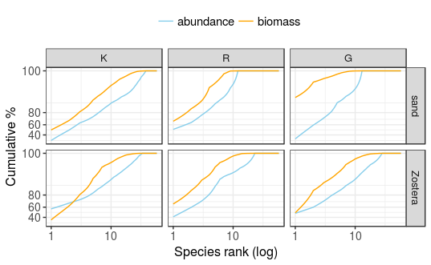

`r`r rm(abc.summary.2012.long)

Spectacularly bad.. For what it’s worth - all the seagrass samples have curves situated close together and sometimes crossing - indicative of slight disturbance, or would be if the underlying data were any good. The sand samples show more or less the same pattern - slight disturbance; site G has the widest distance between curves - but also, let’s not forget, the largest bias because some samples contain only 1-2 species..

Make a combined plot of W and ABC in the Sozopol Bay habitats.

`r`r (plot.abc.w.combined.2012 <- cowplot::plot_grid(plot.summary.abc.2012, plot.w.2012 + theme(legend.position = ), labels = c(, ), ncol = 2, rel_widths = c(2,1)) )

```
Removed 1 rows containing non-finite values (stat_boxplot).
```

`r`r ## save & clean up cowplot::save_plot(here::here(figures.dir, _w_combined_2012.png), plot.abc.w.combined.2012, base_width = 10, base_height = 6, dpi = 300)

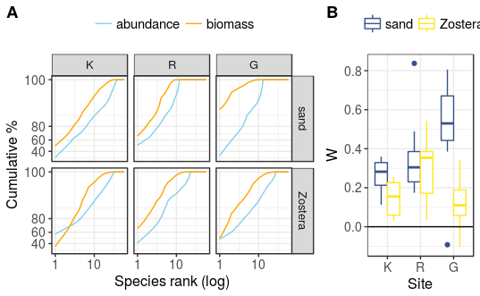

###### **Partial dominance curves**

`r`r ## will be calculated directly on the summarized abundance/biomass data (pd.summary.2012 <- partial_dominance_curves(summary.abnd.2012, summary.biomass.2012, abnd.val = mean_count, biomass.val = mean_biomass, site, habitat) )

| site | habitat | sp_rank | partial_abnd | partial_biomass |
| --- | --- | --- | --- | --- |
| Konski | S | 1 | 29.931973 | 49.92051 |
| Konski | S | 2 | 28.294036 | 36.27758 |
| Konski | S | 3 | 27.272727 | 40.70529 |
| Konski | S | 4 | 14.893617 | 30.85697 |
| Konski | S | 5 | 16.875000 | 38.91303 |
| Konski | S | 6 | 19.172932 | 26.81133 |
| Konski | S | 7 | 18.604651 | 21.59447 |
| Konski | S | 8 | 17.714286 | 24.64286 |
| Konski | S | 9 | 13.888889 | 23.30638 |
| Konski | S | 10 | 15.322581 | 22.10105 |

[output cut: 137 more lines]

`r`r ## reshape the data as before.. pd.summary.2012.long <- pd.summary.2012 %>% gather(key = variable, value = value, -c(site:sp_rank)) %>% mutate(variable = case_when(variable == _abnd ~ , variable == _biomass ~ )) ## plot plot.pd.2012 <- ggplot(pd.summary.2012.long, aes(x = sp_rank, y = value, colour = variable)) + geom_line() + # apply axis transformations scale_x_log10() + # curve colours and legend scale_colour_manual(values = c(, ), name = \) + theme(legend.position = ) + # facets & labels facet_grid(habitat ~ site, labeller = labeller(station = as_labeller(sites.2012), habitat = as_labeller(habitats.2012))) + labs(x = rank (log), y = %) ## modify text size a little (plot.pd.2012 <- plot.pd.2012 + text_size(text.x = rel(1.2), text.y = rel(1.2), legend.text = rel(1), title.x = rel(1.1), title.y = rel(1.1), strip.x = rel(1.1), strip.y = rel(1.1)) ) ## save, just in case, although I don’t much see the point in using ALL of them, when they’re showing basically the same thing.. ggsave(here::here(figures.dir, _pd_2012.png), plot.pd.2012, width = 25, height = 15, units = , dpi = 300)

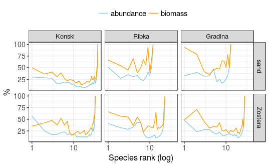

`r`r rm(pd.summary.2012.long)

Very ragged curves, because very few species per sample. The successive removal of the dominants from the calculation makes the incredibly low number of species really obvious, esp. in the sand samples from Ribka and Gradina (the curves are shortish and jump all over the place). Only the samples from Konski somewhat resemble the expected shape of partial dominance curves - because they have more species.. - therefore only they are remotely interpretable. Again, slightly disturbed communities at site K (curves close & sometimes crossing); but no heavy disturbance overall.

**All things considered, for the 2012 samples, again it might be best to summarise at the site level (see mvabund model output in the Community composition notebook). That way, the variability & really, really low species richness might be compensated a little.**